# *DEprot*: R-package for LFQ proteomics data normalization, imputation and Differential Expression analyses

Sebastian Gregoricchio, Ph.D.

Netherlands Cancer Institute, Oncogenomics division, Amsterdam - Netherlands  
s.gregoricchio@nki.nl

Nils Eickhoff, Ph.D.

Netherlands Cancer Institute, Oncogenomics division, Amsterdam - Netherlands  
n.eickhoff@nki.nl

Last update: 07<sup>th</sup> September, 2026

[figure not shown]

[figure not shown]

# 1 **Introduction**

The concept behind *DEprot* (*D*ifferential *E*xpression *prot*eomics) is to provide a toolkit that allows for the normalization, imputation and analyses of the differential protein expression in proteomics data. The data are assumed to be LFQ (label-free quantitation) values.

## 1.1 Citation

If you use this package, please cite:

**Citation**

*DEprot*: a comprehensive R-package for the analyses of label-free quantitation mass-spectrometry data.  
Eickhoff N., Hoekman L., Bleijerveld O., Bergman A.M., Zwart W., Gregoricchio S.  
*NAR Genomics and Bioinformatics* (2026)  
doi: 10.1093/nargab/lqag015

```r
citation("DEprot")
> To cite `DEprot` in publications use:
>
>   N. Eickhoff, L. Hoekman, O. Bleijerveld, A.M. Bergman, W. Zwart, S.
>   Gregoricchio. 'DEprot: a comprehensive R-package for the analyses of
>   label-free quantitation mass-spectrometry data'. NAR Genomics and
>   Bioinformatics (2026)
>
> A BibTeX entry for LaTeX users is
>
>   @Article{,
>     title = {DEprot: a comprehensive R-package for the analyses of label-free quantitation mass-spectrometry data},
>     author = {Nils Eickhoff and Liesbeth Hoekman and Onno Bleijerveld and Andries M. Bergman and Wilbert Zwart and Sebastian Gregoricchio},
>     journal = {NAR Genomics and Bioinformatics},
>     year = {2026},
>     volume = {8},
>     issue = {1},
>     pages = {1-12},
>     url = {https://doi.org/10.1093/nargab/lqag015},
>   }
```

## 1.2 General workflow

Data can be loaded as raw values, pre-normalized unimputed LFQ values or imputed LFQ values. Further, if multiple batches are available, it is possible to perform batch corrections by combining unimputed LFQ tables and loading these data as “raw” in order to perform a batch harmonization.

Using normalized and imputed data, `DEprot` will help you in the differential analyses as well as in performing quality controls on your data (sample correlation, principal components analyses (PCA)).

[figure not shown]

# 2 **Loading the data**

The package starting point is the building of a `DEprot` object. This class of objects is specific to this package and requires at least two elements:

- *counts table*: this must be a matrix in which the column names represent the samples while the row names identify the proteins. The values in the matrix are assumed to be LFQ (label-free quantification) values, either in linear or log-transformed format.
- *metadata*: this must be a data.frame containing at least one column named `column.id`, whose values correspond to the column names of the *counts_table*. Any other additional column can be added (cell lines, treatment, condition, timing, etc) and used to define groups for differential and quality control (PCA and correlation) analyses.

> **NOTE**: the counts table does not need to be prepared by hand: the output of DIA-NN, Spectronaut, FragPipe or MaxQuant can be loaded directly with `import.external()` (see the Import from external tools paragraph).

In the next paragraph we will refer to a dataset (pre-loaded in `DEprot`), in which a breast cancer (BCa) cell line was cultured in either hormone-deprived media or in full media (FBS). If cultured in hormone-deprived condition, it was then treated for 6 hrs with either $\beta$-estradiol (E2) or vehicle (DMSO). 4 biological replicates have been analyzed. Hence, the dataset consists of 1 cell line x 3 conditions x 4 replicates, for a total of 12 samples.  
Proteins and samples have been “anonymized”.

## 2.1 Collect pre-loaded data

The counts represent LFQ values in the log2 format and are not-imputed.

```r
# Metadata
data("sample.config", package = "DEprot")
sample.config
```

**Sample metadata table**

| column.id | sample.id | cell | condition | combined.id | replicate |
| --- | --- | --- | --- | --- | --- |
| Sample_A | BCa_FBS_rep1 | BCa | FBS | BCa_FBS | rep1 |
| Sample_B | BCa_6h.DMSO_rep1 | BCa | 6h.DMSO | BCa_6h.DMSO | rep1 |
| Sample_C | BCa_6h.10nM.E2_rep1 | BCa | 6h.10nM.E2 | BCa_6h.10nM.E2 | rep1 |
| Sample_D | BCa_FBS_rep2 | BCa | FBS | BCa_FBS | rep2 |
| Sample_E | BCa_6h.DMSO_rep2 | BCa | 6h.DMSO | BCa_6h.DMSO | rep2 |
| Sample_F | BCa_6h.10nM.E2_rep2 | BCa | 6h.10nM.E2 | BCa_6h.10nM.E2 | rep2 |
| Sample_G | BCa_FBS_rep3 | BCa | FBS | BCa_FBS | rep3 |
| Sample_H | BCa_6h.DMSO_rep3 | BCa | 6h.DMSO | BCa_6h.DMSO | rep3 |
| Sample_I | BCa_6h.10nM.E2_rep3 | BCa | 6h.10nM.E2 | BCa_6h.10nM.E2 | rep3 |
| Sample_J | BCa_FBS_rep4 | BCa | FBS | BCa_FBS | rep4 |
| Sample_K | BCa_6h.DMSO_rep4 | BCa | 6h.DMSO | BCa_6h.DMSO | rep4 |
| Sample_L | BCa_6h.10nM.E2_rep4 | BCa | 6h.10nM.E2 | BCa_6h.10nM.E2 | rep4 |

```r
# log2(LFQ) values (not imputed)
data("unimputed.counts", package = "DEprot")
head(unimputed.counts[,1:6])
```

**Unimputed log2(LFQ) values**

|  | Sample_A | Sample_B | Sample_C | Sample_D | Sample_E | Sample_F |
| --- | --- | --- | --- | --- | --- | --- |
| protein.1 | 17.8663 | 18.4581 | 18.7380 | 18.1438 | 18.7811 | 19.3043 |
| protein.2 | 22.5238 | 22.9057 | 23.0183 | 22.3577 | 23.0094 | 23.1491 |
| protein.3 | 16.1388 | 15.3720 | 15.2374 | 17.0161 | 15.5452 | 15.7899 |
| protein.4 | 21.0189 | 21.0513 | 21.0460 | 21.2229 | 21.3352 | 21.0178 |
| protein.5 | 19.1038 | 19.4950 | 19.5529 | 18.5697 | 19.3690 | 19.5156 |
| protein.6 | 15.8377 | 15.4202 | 15.4765 | 15.9765 | 15.3439 | 15.2335 |

## 2.2 Build `DEprot` object

Now we will combine the counts and metadata to create a `DEprot` object (hereafter defined as *dpo*).  
Notice that another important point is whether the data are log transformed, and if so, which log base was used. Recommended transformation is the *log<sub>2</sub>(score + 1)*.

If data are pre-normalized and/or pre-imputed, it can be indicated with the corresponding parameter `data.type`, and any information about the method used that you would like to store in the object can be added using the corresponding parameters `normalization.method` and `imputation.method`.

If the metadata table does not contain a `column.id` column corresponding to the column names of the `counts_table`, it is possible to indicate the name of another column that should be assumed to be the `column.id`.

Besides the samples, also the proteins can carry their own annotation. The parameter `protein.info` accepts a data.frame with one row per protein and any number of columns (gene symbol, protein description, number of peptides used for the quantification, etc.). The protein identifiers can be given as row names, in a column called `prot.id`, or in any other column indicated through `protein.info.id.column`. The table does not need to be sorted, nor to be complete: it is reordered on the counts, proteins without annotation are filled with `NA`, and annotations of proteins absent from the counts are discarded.  
From this moment on the annotation follows the counts. Whenever proteins are removed, for instance by `remove.undetected.proteins()` or `filter.proteins()`, the same rows are dropped from the *protein.info* slot, so that the two tables always describe the same proteins.

```r
# Protein annotation
## here a dummy example is generated using the same names of the counts row names
protein.annotation <- data.frame(protein.name = rownames(unimputed.counts))
rownames(protein.annotation) = rownames(unimputed.counts)

head(protein.annotation)
```

**Protein annotation table**

|  | protein.name |
| --- | --- |
| protein.1 | protein.1 |
| protein.2 | protein.2 |
| protein.3 | protein.3 |
| protein.4 | protein.4 |
| protein.5 | protein.5 |
| protein.6 | protein.6 |

```r
dpo <- load.counts2(counts = unimputed.counts,
                    metadata = sample.config,
                    data.type = "raw",
                    log.base = 2,
                    column.id = "column.id",
                    protein.info = protein.annotation) # set as NULL if not available

dpo
> DEprot object:
>            Samples:  12
>           Proteins:  12944
>   Counts available:  raw
> Log transformation:  log2
>   Metadata columns:  column.id, sample.id, cell, condition, combined.id, replicate
>       Protein info:  protein.name
```

The annotation does not need to be provided at loading: it can be attached at any moment to an object built already. Notice that `overwrite = TRUE` is required to replace a table already stored in the object, while `protein.info = NULL` removes it.

```r
dpo <- add.protein.info(DEprot.object = dpo,
                        protein.info = protein.annotation)
```

The annotation stored in an object can be inspected at any moment with `get.protein.info()`, in the same fashion as `get.metadata()` for the samples. The row names of the table returned always correspond to the proteins of the counts, hence the two tables can be combined directly.

```r
head(get.protein.info(dpo))
```

**Protein annotation stored in the object**

|  | protein.name |
| --- | --- |
| protein.1 | protein.1 |
| protein.2 | protein.2 |
| protein.3 | protein.3 |
| protein.4 | protein.4 |
| protein.5 | protein.5 |
| protein.6 | protein.6 |

This object is an S4-vector of class `DEprot`. The S4-vectors are containers of slots that can be accessed using the symbol `@` (or `$` from version >1.3.0) (e.g., `object@slot.id`).  
The structure of an object of class `DEprot` (and `DEprot.analyses`) is the following:

| Slot | Description |
| --- | --- |
| *metadata* | data.frame describing the samples: it always contains a `column.id` column matching the column names of the counts, plus any other sample feature (cell line, condition, replicate, etc.) |
| *protein.info* | table of extra information about the proteins (gene symbol, description, etc.), if not available it will be `NULL` |
| *raw.counts* | table containing the raw counts, if not available it will be `NULL` |
| *norm.counts* | table containing the normalized counts, if not available it will be `NULL` |
| *random.counts* | table containing the randomized counts, if not available it will be `NULL` |
| *imputed.counts* | table containing the imputed counts, if not available it will be `NULL` |
| *log.base* | a number indicating the base of the log used to transform the table, if not available it will be `NA` |
| *log.transformed* | logical value indicating whether the data are log-transformed or not |
| *normalized* | logical value indicating whether the data are normalized or not |
| *normalization.method* | a string indicating the type of normalization applied, if not available it will be `NA` |
| *randomized* | logical value indicating whether the data have been randomized or not |
| *randomization.method* | a list indicating the type of randomization applied, if not available it will be `NA` |
| *imputed* | logical value indicating whether the data are imputed or not |
| *imputation.method* | discussed further in the Imputation paragraph |
| *boxplot.raw* | box+violin plot of the distribution of the LFQ intensities per sample obtained from the raw counts |
| *boxplot.norm* | box+violin plot of the distribution of the LFQ intensities per sample obtained from the normalized counts |
| *boxplot.random* | box+violin plot of the distribution of the LFQ intensities per sample obtained from the randomized counts |
| *boxplot.imputed* | box+violin plot of the distribution of the LFQ intensities per sample obtained from the imputed counts |
| *analyses.result.list* | discussed further in the Differential Expression analyses paragraph |
| *contrasts* | discussed further in the Differential Expression analyses paragraph |
| *differential.analyses.params* | discussed further in the Differential Expression analyses paragraph |

## 2.3 Rename sample columns

As in our example, sometimes the column names of the counts are not the actual names of the samples, but rather an internal identifier. However, it is possible to rename the counts columns by indicating any column of the metadata table (having unique values). The original identifiers are stored in a new column (`old.column.id`) of the metadata.  
Notice that the renaming will be applied to all the counts tables available.

```r
dpo <- rename.samples(DEprot.object = dpo,
                      metadata.column = "sample.id")

get.metadata(dpo)
>              column.id           sample.id cell  condition    combined.id
> 1         BCa_FBS_rep1        BCa_FBS_rep1  BCa        FBS        BCa_FBS
> 2     BCa_6h.DMSO_rep1    BCa_6h.DMSO_rep1  BCa    6h.DMSO    BCa_6h.DMSO
> 3  BCa_6h.10nM.E2_rep1 BCa_6h.10nM.E2_rep1  BCa 6h.10nM.E2 BCa_6h.10nM.E2
> 4         BCa_FBS_rep2        BCa_FBS_rep2  BCa        FBS        BCa_FBS
> 5     BCa_6h.DMSO_rep2    BCa_6h.DMSO_rep2  BCa    6h.DMSO    BCa_6h.DMSO
> 6  BCa_6h.10nM.E2_rep2 BCa_6h.10nM.E2_rep2  BCa 6h.10nM.E2 BCa_6h.10nM.E2
> 7         BCa_FBS_rep3        BCa_FBS_rep3  BCa        FBS        BCa_FBS
> 8     BCa_6h.DMSO_rep3    BCa_6h.DMSO_rep3  BCa    6h.DMSO    BCa_6h.DMSO
> 9  BCa_6h.10nM.E2_rep3 BCa_6h.10nM.E2_rep3  BCa 6h.10nM.E2 BCa_6h.10nM.E2
> 10        BCa_FBS_rep4        BCa_FBS_rep4  BCa        FBS        BCa_FBS
> 11    BCa_6h.DMSO_rep4    BCa_6h.DMSO_rep4  BCa    6h.DMSO    BCa_6h.DMSO
> 12 BCa_6h.10nM.E2_rep4 BCa_6h.10nM.E2_rep4  BCa 6h.10nM.E2 BCa_6h.10nM.E2
>    replicate old.column.id
> 1       rep1      Sample_A
> 2       rep1      Sample_B
> 3       rep1      Sample_C
> 4       rep2      Sample_D
> 5       rep2      Sample_E
> 6       rep2      Sample_F
> 7       rep3      Sample_G
> 8       rep3      Sample_H
> 9       rep3      Sample_I
> 10      rep4      Sample_J
> 11      rep4      Sample_K
> 12      rep4      Sample_L
```

```r
head(dpo@raw.counts[,1:6])
>           BCa_FBS_rep1 BCa_6h.DMSO_rep1 BCa_6h.10nM.E2_rep1 BCa_FBS_rep2
> protein.1      17.8663          18.4581             18.7380      18.1438
> protein.2      22.5238          22.9057             23.0183      22.3577
> protein.3      16.1388          15.3720             15.2374      17.0161
> protein.4      21.0189          21.0513             21.0460      21.2229
> protein.5      19.1038          19.4950             19.5529      18.5697
> protein.6      15.8377          15.4202             15.4765      15.9765
>           BCa_6h.DMSO_rep2 BCa_6h.10nM.E2_rep2
> protein.1          18.7811             19.3043
> protein.2          23.0094             23.1491
> protein.3          15.5452             15.7899
> protein.4          21.3352             21.0178
> protein.5          19.3690             19.5156
> protein.6          15.3439             15.2335
```

# 3 **Data normalization**

When a `DEprot` object is loaded, automatically a box/violin plot showing the distribution of the LFQ values per samples is generated.  
This representation is useful to estimate whether the data are normalized or not. Boxplots display the quantiles of the LFQ intensities, while red and blue dashed lines correspond to maximum and minimum LFQ value for each sample.

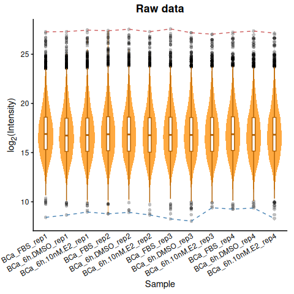

```r
dpo@boxplot.raw
```

In this package we apply the Modified Balanced Quantile Normalization (MBQN) from the [`MBQN`](https://www.bioconductor.org/packages/release/bioc/html/MBQN.html) package, developed by [E.Brombacher *et al.* (*Proteomics*, 2020)](https://doi.org/10.1002/pmic.202000068). The modification balances the median (or mean) intensity of features (rows) which are rank invariant (RI) or nearly rank invariant (NRI) across samples (columns) before quantile normalization. This prevents an over-correction of the intensity profiles of RI and NRI features by classical quantile normalization and therefore supports the reduction of systematics in downstream analyses.

```r
dpo <- normalize.counts(DEprot.object = dpo,
                        NRI.RI.ratio.threshold = 0.5,
                        balancing.function = "median")

dpo
> DEprot object:
>            Samples:  12
>           Proteins:  12944
>   Counts available:  raw, normalized
> Log transformation:  log2
>   Metadata columns:  column.id, sample.id, cell, condition, combined.id, replicate, old.column.id
>       Protein info:  protein.name
```

```r
dpo@normalization.method
>                    param                  value
> 1                package                   MBQN
> 2                 method Quantile normalization
> 3               balanced                   TRUE
> 4               function                 median
> 5 NRI/RI ratio threshold                    0.5
```

```r
head(dpo@raw.counts[,1:6])
>           BCa_FBS_rep1 BCa_6h.DMSO_rep1 BCa_6h.10nM.E2_rep1 BCa_FBS_rep2
> protein.1      17.8663          18.4581             18.7380      18.1438
> protein.2      22.5238          22.9057             23.0183      22.3577
> protein.3      16.1388          15.3720             15.2374      17.0161
> protein.4      21.0189          21.0513             21.0460      21.2229
> protein.5      19.1038          19.4950             19.5529      18.5697
> protein.6      15.8377          15.4202             15.4765      15.9765
>           BCa_6h.DMSO_rep2 BCa_6h.10nM.E2_rep2
> protein.1          18.7811             19.3043
> protein.2          23.0094             23.1491
> protein.3          15.5452             15.7899
> protein.4          21.3352             21.0178
> protein.5          19.3690             19.5156
> protein.6          15.3439             15.2335
```

Also in this case a box/violin plot with the corresponding normalized LFQ values per each sample is generated and stored in a vector slot.

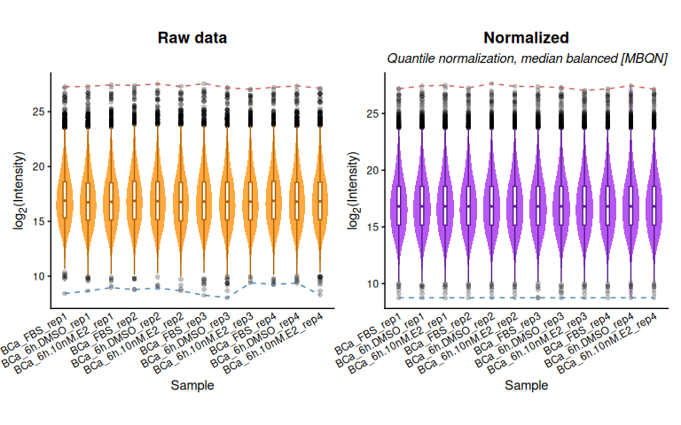

```r
plot(dpo, nrow = 1)
```

## 3.1 Batch effect correction

Proteomics is highly susceptible to batch effects. Hereafter we use the [`HarmonizR`](https://www.bioconductor.org/packages/release/bioc/html/HarmonizR.html) package, developed by [H.Voß & S.Schlumbohm (*Nat.Commun.*, 2022)](https://doi.org/10.1038/s41467-022-31007-x). This tool, besides handling multiple experiments, allows for the batch correction of data derived from the combination of both DIA (Data-Independent Acquisition) and DDA (Data-Dependent Acquisition).

> `HarmonizR` is not a required dependency, therefore if this function is used and `HarmonizR` is not already installed, a warning will indicate the required installation. The package can be installed by: `BiocManager::install("HarmonizR")`, or alternatively `devtools::install_github("https://github.com/SimonSchlumbohm/HarmonizR/", subdir = "HarmonizR")`.

To use `harmonize.batches` it is sufficient to provide a `DEprot` object containing a combined table of multiple experiments and indicate the identifier of a column in the metadata table which corresponds to the batch annotation. The result is a `DEprot` object with the same structure described in the previous paragraph.  
Here, for simplicity, we will add manually a column to the metadata table with “dummy” batches.

> Batch harmonization replaces the normalization: so data can be loaded as ‘raw’ and “normalized” using `harmonize.batches`. Do not apply additional MBQN normalization.

```r
## Adding batch column to the metadata table
dpo@metadata$batch = rep(c("batch_1","batch_2"), each = 6)

get.metadata(dpo)
```

```
>              column.id           sample.id cell  condition    combined.id
> 1         BCa_FBS_rep1        BCa_FBS_rep1  BCa        FBS        BCa_FBS
> 2     BCa_6h.DMSO_rep1    BCa_6h.DMSO_rep1  BCa    6h.DMSO    BCa_6h.DMSO
> 3  BCa_6h.10nM.E2_rep1 BCa_6h.10nM.E2_rep1  BCa 6h.10nM.E2 BCa_6h.10nM.E2
> 4         BCa_FBS_rep2        BCa_FBS_rep2  BCa        FBS        BCa_FBS
> 5     BCa_6h.DMSO_rep2    BCa_6h.DMSO_rep2  BCa    6h.DMSO    BCa_6h.DMSO
> 6  BCa_6h.10nM.E2_rep2 BCa_6h.10nM.E2_rep2  BCa 6h.10nM.E2 BCa_6h.10nM.E2
> 7         BCa_FBS_rep3        BCa_FBS_rep3  BCa        FBS        BCa_FBS
> 8     BCa_6h.DMSO_rep3    BCa_6h.DMSO_rep3  BCa    6h.DMSO    BCa_6h.DMSO
> 9  BCa_6h.10nM.E2_rep3 BCa_6h.10nM.E2_rep3  BCa 6h.10nM.E2 BCa_6h.10nM.E2
> 10        BCa_FBS_rep4        BCa_FBS_rep4  BCa        FBS        BCa_FBS
> 11    BCa_6h.DMSO_rep4    BCa_6h.DMSO_rep4  BCa    6h.DMSO    BCa_6h.DMSO
> 12 BCa_6h.10nM.E2_rep4 BCa_6h.10nM.E2_rep4  BCa 6h.10nM.E2 BCa_6h.10nM.E2
>    replicate old.column.id   batch
> 1       rep1      Sample_A batch_1
> 2       rep1      Sample_B batch_1
> 3       rep1      Sample_C batch_1
> 4       rep2      Sample_D batch_1
> 5       rep2      Sample_E batch_1
> 6       rep2      Sample_F batch_1
> 7       rep3      Sample_G batch_2
> 8       rep3      Sample_H batch_2
> 9       rep3      Sample_I batch_2
> 10      rep4      Sample_J batch_2
> 11      rep4      Sample_K batch_2
> 12      rep4      Sample_L batch_2
```

```r
## batch correction
dpo <- harmonize.batches(DEprot.object = dpo,
                         batch.column = "batch",
                         cores = 1)
```

> NOTE: By default `harmonize.batches` uses `ComBat`. If your batch design is sparse (i.e., a batch with a single sample, or proteins measured only once in a batch) ComBat can fail with a singular-matrix error; see next paragraph to know how to fix it using `limma` instead.

### 3.1.1 When to use `limma` instead of `ComBat`

The function `harmonize.batches` runs `ComBat` by default. ComBat adjusts each batch for both its mean and its variance, which is the right model when batches differ in spread as well as in level. The catch is that estimating a per-batch variance needs at least 2 values per batch. When a batch has a single sample, or a protein is measured only once within a batch, the sub-matrix ComBat tries to solve becomes singular and the run stops with an error such as `Lapack routine dgesv: system is exactly singular`.

For these cases, set `algorithm = "limma"`. `limma`’s `removeBatchEffect` corrects the batch means only, so it handles sparse and small batches that ComBat cannot. The trade-off is that real variance differences between batches stay in the data, so keep ComBat as the default and switch to limma when your batch design is too sparse for it.

```r
dpo <- harmonize.batches(DEprot.object = dpo,
                         batch.column = "batch",
                         algorithm = "limma",
                         cores = 1)
```

# 4 **Data imputation**

Often many `NA`/`NaN` values are present in the LFQ tables due to the technical limitations of the protein detection in Mass Spectrometry (MS) experiments.

Here we provide the possibility to use 9 different methods for the imputation of the data:

- [`missForest`](https://www.rdocumentation.org/packages/missForest/): developed by [DJ.Stekhoven & P.Buehlmann (*Bioinformatics*, 2012)](https://doi.org/10.1093/bioinformatics/btr597), this tool will impute the NaNs and assign an estimated value. It also yields an out-of-bag (OOB) imputation error estimate (general, or for each sample). Moreover, it can be run in parallel to save computation time (both examples reported hereafter).
- k-Nearest Neighbors (kNN) algorithm
- correlation-Nearest Neighbors (corkNN) algorithm
- truncated-Nearest Neighbors (tkNN) algorithm
- Local Least Squares (LLS) imputation, using the pearson correlation coefficient
- Singular Value Decomposition (SVD)
- Glmnet ridge regression (RegImpute, from DreamAI)
- Probabilistic Principal Component Analysis (PPCA)
- Bayesian Principal Component Analysis (BPCA)

Of note, there are cases in which the missing data are not random but rather the consequence of real biological effects (i.e., knock-down, knock-out, degron systems and PROTACs, etc.). This may lead to the issue that a protein completely missing in all the replicates of an individual condition will be imputed with relatively high numbers. This would ultimately lead to the incorrect definition of the differential status of this protein. To overcome this, it is possible to use the function `randomize.missing.values` to assign random values from the bottom distribution of the full dataset. The user can define a percentage threshold of minimal missing values within the group; for instance if the threshold is 75% and in each group there are 4 samples, it means that only proteins with at least 3 out of 4 missing values will be imputed. It will be sufficient to indicate the ID of a column belonging to the metadata which indicates the groups/conditions and the percentage of distribution from which to select random numbers (“tail.percentage”).

```r
dpo <- randomize.missing.values(DEprot.object = dpo,
                                group.column = "combined.id",
                                percentage.missing = 100, # completely missing
                                tail.percentage = 3,
                                seed = 1234,
                                verbose = FALSE)
```

> Using the `"column.id"` as *group.column* is equivalent to impute all the data with this method.

## 4.1 Missingness diagnostics

Before choosing randomization/imputation strategy it is worth asking *why* the values are missing. As briefly mentioned before, two mechanisms are usually mixed in the same LFQ table: values that are absent because the protein was below the detection limit of the instrument (MNAR, *missing not at random*, or left-censored) and values that are absent for reasons unrelated to the abundance, such as a failed identification in a single run (MCAR, *missing completely at random*). The two require opposite treatments. Replacing a left-censored value with an estimate derived from the other replicates pushes it upwards, which is exactly the artefact that `randomize.missing.values` avoids; conversely, assigning a value from the bottom of the distribution to a protein that was simply not identified in one run out of twelve introduces a fold change that does not exist.

The function `missingness.diagnostic` describes the structure of the missing values and classifies them following the same rule used by the double-imputation strategy of `DEprot`: within each group of replicates, a protein missing in at least `percentage.missing`% of the samples is flagged as MNAR-like (it would be replaced by `randomize.missing.values` using the bottom `tail.percentage`% of the distribution), while all the remaining missing values are flagged as MCAR-like (they would be replaced by `impute.counts`).

The counts used are chosen automatically: since randomization and imputation both fill the `NA`s, the function takes the lowest level available following the priority raw > normalized > randomized > imputed, and stops if only imputed counts are found. If `randomize.missing.values` has already been run, the parameters (`group.column`, `percentage.missing`, `tail.percentage`) are read back from the object, so that the diagnostic mirrors the treatment actually applied; otherwise the defaults of `randomize.missing.values` are used and any of them can be overwritten manually.

```r
miss <- missingness.diagnostic(DEprot.object = dpo,
                               verbose = FALSE)

miss
> DEprot.missingness object:
>            Counts used:  raw (available: raw, normalized, randomized)
>               Proteins:  12944
>                Samples:  12
>           Group column:  combined.id
>      MNAR defined when:  >= 100% missing values within a group
>             Parameters:  randomization
>
>         Missing values:  10481/155328 (6.75%)
>         of which MNAR:  3056 (29.2% of the missing values)
>         of which MCAR:  7425 (70.8% of the missing values)
>
>   Estimated LOD50:  12.186
>     Dropout slope:  -0.984 (p = <2e-16)
>   Intensity shift:  incomplete - complete = -3.571 (p = <2e-16)
>
>   Interpretation:  the missingness is intensity-dependent (MNAR/left-censoring is dominant).
>
> Proteins per missing-value class:
>   missing.class n.proteins percentage
> 1      complete      10646  82.246601
> 2          MCAR       1772  13.689740
> 3          MNAR        526   4.063659
> 4   all.missing          0   0.000000
```

> The parameters are retrieved from the randomization run above; passing `group.column`, `percentage.missing` or `tail.percentage` explicitly overrides them, which is useful to check how many proteins would change class with a different threshold.

### 4.1.1 Reading the diagnostic plots

The default `plot` call combines the four panels that are most informative for the choice of the strategy; each plot is stored individually in the `plots` slot and can be recalled with the `plot.type` argument (`"density"`, `"dropout"`, `"heatmap"`, `"samples"`, `"frequency"`, `"classes"`, `"similarity"`, `"upset"`, `"contrasts"`, or `"all"`).

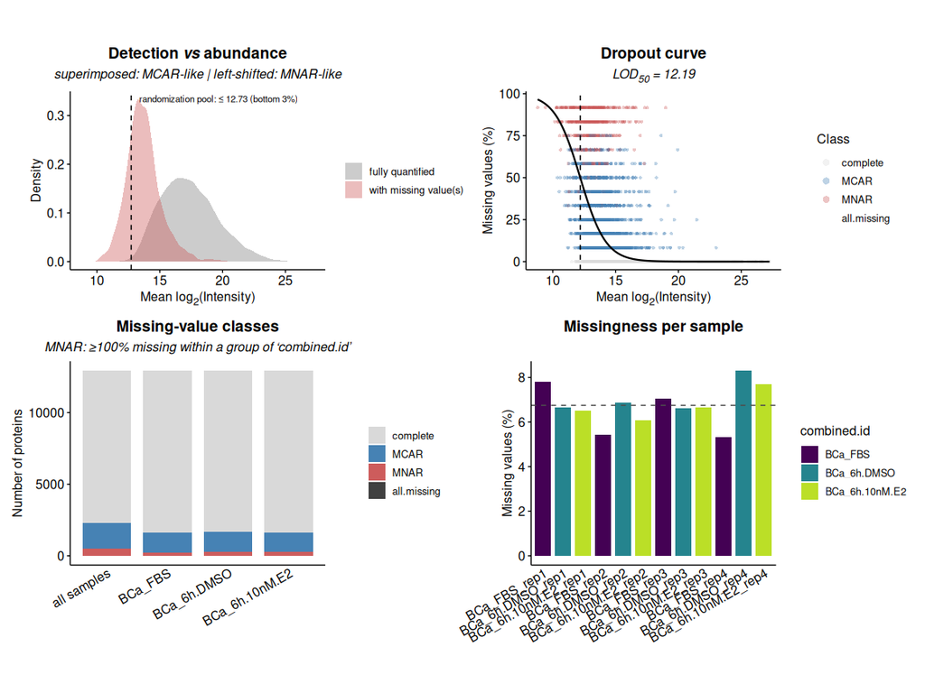

```r
plot(miss, ncol = 2)
```

#### 4.1.1.1 Detection *vs* abundance

The first panel compares the distribution of the average intensity of the proteins quantified in all the samples with that of the proteins showing at least one missing value. If the two densities overlap, the missing values are spread over the whole dynamic range and are compatible with a MCAR mechanism. If the incomplete proteins are shifted to the left, their absence is a function of their abundance, which is the signature of left-censoring. The dashed line marks the intensity threshold corresponding to the bottom `tail.percentage`% of the distribution, that is the pool from which `randomize.missing.values` samples the replacement values.

#### 4.1.1.2 Dropout curve

This panel puts numbers on what the density plot shows qualitatively.

Each point is a protein: on the x-axis its mean intensity computed over the samples in which it was measured, on the y-axis the percentage of samples in which it is missing. Proteins quantified everywhere sit on the bottom line, proteins detected only sporadically sit at the top. The black curve is a logistic regression of the number of missing values over the total number of samples as a function of the mean intensity (`glm(cbind(n.missing, n.detected) ~ mean.intensity, family = binomial)`), and the corresponding model is stored in the `dropout.model` slot.

The fit is summarized by the following metrics, all available in `global.stats`:

- **`dropout.slope`**: the slope of the logistic model, on the logit scale. A negative slope means that the probability of a value being missing decreases as the abundance increases, the typical behavior of a detection limit. A slope close to zero describes missing values scattered over the whole intensity range, independently of the abundance.
- **`dropout.pvalue`**: the p-value of the slope. With several thousand proteins even a very shallow slope reaches significance, therefore we suggest to look at the magnitude of the slope and at the shape of the curve, and not at the p-value alone.
- **`LOD50`**: the intensity at which the model predicts 50% of missing values, computed as `-intercept/slope`. It is an empirical estimate of the limit of detection of the experiment and it is drawn as a vertical dashed line. It is reported only when it falls inside the range of the observed intensities: when the dropout is shallow the 50% point lies far outside the data and an extrapolated value would be meaningless, hence `NA` is returned instead.
- **`intensity.shift.pvalue`**: the one-sided Wilcoxon test comparing the mean intensity of the incomplete proteins with that of the complete ones. The two medians are reported as well (`median.intensity.incomplete` and `median.intensity.complete`).

The `show` method combines slope and p-value into a one-line interpretation of the dominant mechanism.

Of note, two comparisons make these values actionable. The first one is `LOD50` against the threshold of the randomization pool (`tail.threshold`, the dashed line of the density panel): when the pool sits at or below the estimated detection limit, the values drawn by `randomize.missing.values` fall in the region where the instrument stops detecting, which is the assumption on which the method is built. A pool sitting well above `LOD50` means that the randomized values are higher than the censoring point and the fold changes of the MNAR proteins will be compressed; lowering `tail.percentage` corrects it.

The second comparison involves the fraction of missing values that are MNAR-like (`perc.missing.MNAR`). A steep dropout curve combined with a low MNAR fraction indicates that most of the censored values are scattered instead of being concentrated within a group, hence they will be handled by the imputation and not by the randomization.

> **NOTE**: pay attention when reading the top of the plot. The mean intensity is computed on the observed values only, so a protein missing in most of the samples has its abundance estimated from the few measurements that survived, i.e. the ones that happened to be above the detection limit. This inflates the abundance of the highly incomplete proteins and flattens the right tail of the curve, so the real dropout is usually somewhat steeper than the fitted one. For this reason `LOD50` is best used as an internal reference to compare datasets processed in the same way, and not as a physical property of the instrument.

#### 4.1.1.3 Missing-value classes and missingness pattern

The bar plot counts the proteins per class, both globally and within each group of replicates: `complete` (no missing value), `MCAR` (missing values below the group threshold), `MNAR` (at least one group above the threshold) and `all.missing` (never detected). The proteins in the last class carry no information and are the ones to remove before testing.

The heatmap (`plot.type = "heatmap"`) shows the same classification at the level of the single value. Each cell is colored according to the treatment that the double-imputation strategy would apply to it, so the plot doubles as a map of what is about to be modified in the counts table: the cells marked as MNAR-like will receive a random value from the bottom of the distribution, the ones marked as MCAR-like will be imputed. Proteins are clustered on the binary detection pattern and the samples are grouped by condition, which makes the blocks of condition-specific absence immediately visible. The same information is stored, without subsampling, in the `imputation.map` slot.

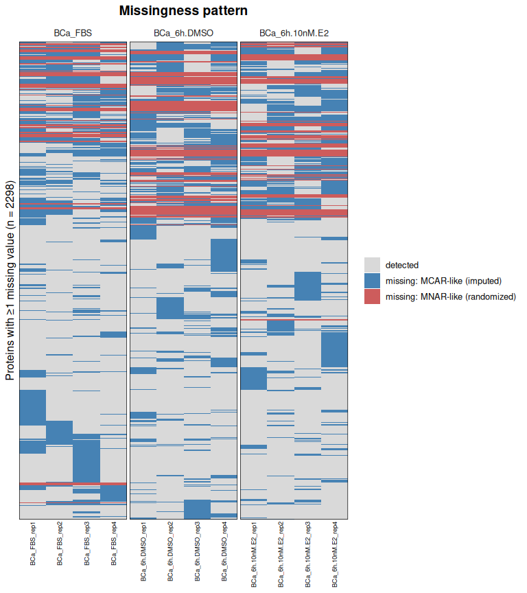

```r
plot(miss, plot.type = "heatmap")
```

#### 4.1.1.4 Sample-level diagnostics

Two panels describe the samples rather than the proteins. The bar plot of the percentage of missing values per sample (`plot.type = "samples"`) identifies runs of lower quality; a single sample well above the average is usually a technical problem and is a candidate for exclusion. The heatmap of the Jaccard similarity between detection patterns (`plot.type = "similarity"`) compares which proteins were detected in which sample: the samples are clustered on `1 - Jaccard` and the dendrogram is drawn on the left. If the clusters follow the experimental conditions, part of the missingness is biological; if they follow the batches or the acquisition order, the missingness is structured by a technical factor and the imputation should be evaluated with that in mind. The matrix and the `hclust` object are kept in the `jaccard.matrix` and `jaccard.cluster` slots.

Finally, `plot.type = "frequency"` gives the number of proteins as a function of the number of samples in which they were detected. The distribution is typically bimodal, with a peak on the right corresponding to the core proteome and a peak on the left corresponding to the sporadic identifications, while `plot.type = "upset"` shows how the MNAR-like proteins are shared between the groups.

### 4.1.2 Contrast-level diagnostics

When a `DEprot.analyses` object is used as input, the diagnostic is repeated on the samples of each contrast and the results are collected in the `contrast.stats` slot (use the `contrasts` argument to restrict the analysis to a subset, or `contrasts = "none"` to skip it). Within a contrast the classification becomes directional: besides `complete` and `MCAR`, a protein can be MNAR in the first group, MNAR in the second, or missing in both. The last case is reported in the `testable` column as `FALSE`, since a protein absent from both sides carries no information for that comparison whatever value the imputation assigns to it. The two plots of each contrast (`plot(miss, plot.type = "contrasts")`) show the number of proteins per class and the detection *vs* abundance densities restricted to those samples, and `summary()` returns the same counts for all the contrasts in a single table.

The `DEprot.missingness` object contains the following slots:

[output not shown]

## 4.2 Choice of the imputation method

We implemented the function `compare.imp.methods` to compare the different imputation methods and choose the most suitable one for your data type. A subset of the table is taken, part of the measured values is hidden reproducing the proportion and the pattern of the missing values of the original data, the hidden values are imputed with each method and then compared with the measurements. What the score describes is therefore the reconstruction of values that had been measured and were removed on purpose, which is not the same question as *which method reconstructs best the values that are actually missing*: those have no measurement to be compared with, and no benchmark can reach them.

Two parameters address the two halves of the problem.

The first is `max.NA.per.row`. Since the error is computed only on the cells that are masked, a protein does not need to be complete to be usable: it is enough that the masked value was measured, and the missing values elsewhere in the same protein are handled by the algorithms exactly as they would be in the real table. Allowing a few of them recovers the low-abundance proteins: with `max.NA.per.row = 4` the usable proteins of `unimputed.counts` go from 10,646 to 11,975, and the fraction of the bottom 3% of the values that the masking can reach rises from 19% to 69%. The ceiling is set by `max.NA.fraction`: the masked cells that would push a protein above it are discarded, which keeps the test dataset usable by the algorithms that require a minimum number of measured values per protein, `missForest` in the first place.

The second is `masking`. With the default, `"MCAR"`, every measured value has the same probability of being hidden. With `"intensity"` the probability follows a logistic dropout curve estimated on the data,

$$P(\text{missing}) = \frac{1}{1 +
e^{-(a\, +\, b \cdot \text{abundance})}}$$

and the masked values are consequently drawn from the bottom of the distribution with the same rate at which the values are really lost. One curve is estimated for each group of replicates (`dropout.by = "group"`, the levels of `sample.group.column`) or for each sample (`dropout.by = "sample"`). This is where the structure of the experiment enters the simulation: an IgG control and an IP do not have the same detection depth, they do not lose the values in the same intensity range, and a single curve fitted on all the samples together would describe neither of the two. The curves are estimated on the complete table and not on the test subset, because the proteins absent from an entire group are the ones carrying the information about the detection limit and they cannot, by construction, belong to a test dataset made of measured values. When a curve cannot be estimated, or when it increases with the abundance, the samples concerned fall back to the uniform masking and a warning reports which ones.

The pattern of the missing values per group is preserved in both modes: the number of proteins missing in 1, 2, … n replicates of each group is reproduced in the test dataset, and only the choice of *which* proteins and *which* replicates is weighted by the dropout curves.

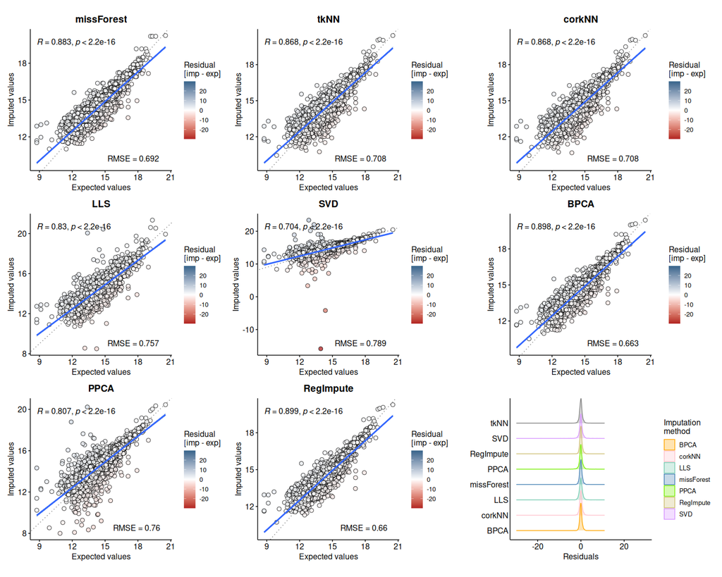

```
>            imputation.method      RMSE correlation.coeff processing.time rank
> RegImpute          RegImpute 0.6601285         0.8989965           12.43    1
> BPCA                    BPCA 0.6626976         0.8976505          159.60    2
> missForest        missForest 0.6923792         0.8827868           34.10    3
> tkNN                    tkNN 0.7080672         0.8683818            3.03    4
> corkNN                corkNN 0.7081231         0.8680934            2.55    5
> LLS                      LLS 0.7571358         0.8301528            5.58    6
> PPCA                    PPCA 0.7595902         0.8072285            1.40    7
> SVD                      SVD 0.7890931         0.7038743            6.21    8
```

```r
imp.comparison <- compare.imp.methods(DEprot.object = dpo,
                                      percentage.test = 30,
                                      sample.group.column = "combined.id",
                                      which.data = "normalized",
                                      masking = "intensity",
                                      max.NA.per.row = 4,
                                      dropout.by = "group",
                                      seed = 42,
                                      run.kNN = FALSE, # time consuming
                                      verbose = FALSE)
> [1] "Back Filling With Method:  row_mean"
> [1] "Starting Imputation With  10  Max. Iterations"
> [1] "Working on Iteration:  1 / 10"
> [1] "Working on Iteration:  2 / 10"
> [1] "NRMSE =  0.0336634949389279"
> [1] "Working on Iteration:  3 / 10"
> [1] "NRMSE =  0.00999982678860451"
> [1] "Working on Iteration:  4 / 10"
> [1] "NRMSE =  0.00355027816395221"
> [1] "Working on Iteration:  5 / 10"
> [1] "NRMSE =  0.00138853786413096"
> [1] "Working on Iteration:  6 / 10"
> [1] "NRMSE =  0.000570453144929666"
> [1] "Working on Iteration:  7 / 10"
> [1] "NRMSE =  0.000240224616486363"
> [1] "Working on Iteration:  8 / 10"
> [1] "NRMSE =  0.000102665936171963"
> [1] "Working on Iteration:  9 / 10"
> [1] "NRMSE =  4.43066683441138e-05"
> [1] "Working on Iteration:  10 / 10"
> [1] "NRMSE =  1.92559053823341e-05"

patchwork::wrap_plots(c(imp.comparison@correlation.plots,
                        imp.comparison@density.residuals))
```

The masking settings and the estimated curves are stored in the `masking` slot of the `DEprot.RMSE` object, so that a comparison can be reproduced and, above all, so that the range on which it was run can be reported. The slope is negative when the probability of losing a value decreases with the abundance, and its magnitude describes how sharply: here the three groups behave in the same way, while a control and an enrichment would not.

```r
data.frame(do.call(rbind, imp.comparison@masking$dropout.curves))
```

**Dropout curves estimated for each group of replicates**

|  | intercept | slope |
| --- | --- | --- |
| BCa_FBS | 10.937 | -0.913 |
| BCa_6h.DMSO | 12.682 | -1.028 |
| BCa_6h.10nM.E2 | 12.398 | -1.014 |

Two remarks on how to read the ranking. The score is the reconstruction error of the masked intensities, not the performance of the differential analysis that follows: a lower RMSE does not automatically give a better balance between true and false positives in `diff.analyses`, and the comparison is more useful to discard the methods that behave badly on your data than to declare a winner by a small margin. And whichever mode is used, the values missing at the very bottom of the distribution remain out of reach, because a value that was never measured cannot be put back and scored. If the missingness of your dataset is largely structured, the alternative is not a better imputation but a model that keeps the missing values as such, such as the one used by `diff.analyses.proDA`.

## 4.3 Apply imputation

Hereafter, an example in how to use the `missForest` method to impute the data:

```r
## Without parallelization
dpo <- impute.counts(DEprot.object = dpo,
                     method = "missForest",
                     which.data = "randomized",
                     missForest.max.iterations = 100,
                     missForest.variable.wise.OOBerror = TRUE,
                     seed = 1234)


## With parallelization
dpo <- impute.counts(DEprot.object = dpo,
                     method = "missForest",
                     which.data = "randomized",
                     missForest.max.iterations = 100,
                     missForest.variable.wise.OOBerror = TRUE,
                     missForest.cores = 20,
                     missForest.parallel.mode = "variables",
                     seed = 1234)

dpo

head(dpo@imputation.method$OOBerror)

data.frame(dpo@imputation.method[-3])
```

```
> DEprot object:
>            Samples:  12
>           Proteins:  12944
>   Counts available:  raw, normalized, randomized, imputed
> Log transformation:  log2
>   Metadata columns:  column.id, sample.id, cell, condition, combined.id, replicate, old.column.id
```

```
>        BCa_FBS_rep1    BCa_6h.DMSO_rep1 BCa_6h.10nM.E2_rep1        BCa_FBS_rep2
>                   0                   0                   0                   0
>    BCa_6h.DMSO_rep2 BCa_6h.10nM.E2_rep2
>                   0                   0
```

| method | max.iterations | parallelization.mode | cores | processing.time | seed |
| --- | --- | --- | --- | --- | --- |
| missForest | 100 | variables | 20 | 1.67 hours | 1234 |

Also in this case a box/violin plot with the corresponding imputed LFQ values per each sample is generated and stored in a vector slot.

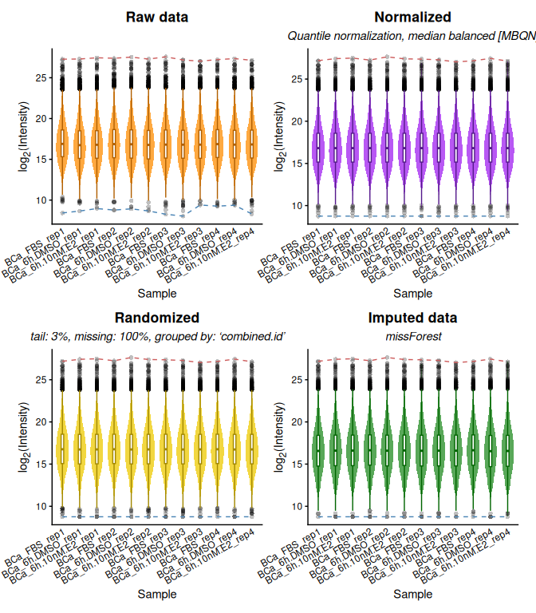

```r
plot(dpo, ncol = 2)
```

# 5 **Sample similarities**

## 5.1 Principal Component Analyses (PCA)

PCA can be used to perform a dimensionality reduction and determine which factor explains the variability of the samples.  
`DEprot` includes functions dedicated to this aim and specifically built to work with `DEprot` objects.

Notice that, even if the data are not log-transformed, `perform.PCA` will do it before performing the analyses.

### 5.1.1 Compute PCs

```r
## Perform the analyses (DEprot.PCA object)
PCA <- perform.PCA(DEprot.object = dpo,
                   which.data = "imputed") # possible: raw, normalized, imputed
```

The `DEprot.PCA` object contains the following slots:

| Slot | Description |
| --- | --- |
| *PCA.metadata* | metadata of the samples used in the PCA (subset of the original `DEprot@metadata`) |
| *sample.subset* | vector containing the list of samples analyzed |
| *data.used* | vector indicating the type of counts used (imputed, normalized, raw) |
| *prcomp* | object of class `prcomp` corresponding to the full PCA output |
| *PCs* | `data.frame` combining the PC scores and the metadata table, useful for replotting |
| *importance* | statistical summary table for the PCA analyses per each PC |
| *cumulative.PC.plot* | `ggplot` object corresponding to the output of `plot.PC.cumulative` for this object |

### 5.1.2 Visualize PCAs

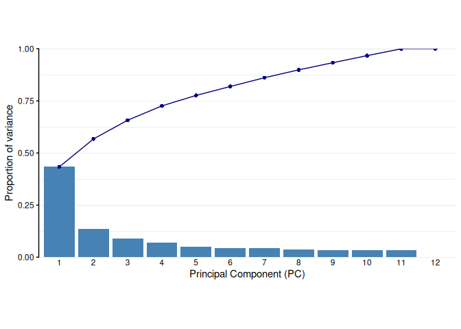

```r
## Plot cumulative variance of all PCs
#### equivalent to `PCA@cumulative.PC.plot`
plot.PC.cumulative(DEprot.PCA.object = PCA,
                   bar.color = "steelblue",
                   line.color = "navyblue")
```

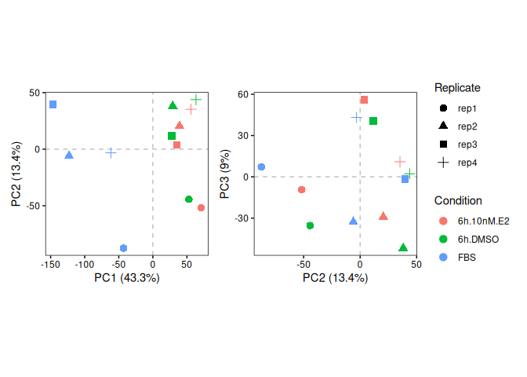

```r
## Plot PC scatters
PC_1.2 <-
  plot.PC.scatter(DEprot.PCA.object = PCA,
                  PC.x = 1,
                  PC.y = 2,
                  color.column = "condition",
                  shape.column = "replicate",
                  label.column = NULL,
                  plot.zero.line.x = TRUE,
                  plot.zero.line.y = TRUE) +
  theme(legend.position = "none")


PC_2.3 <-
  plot.PC.scatter(DEprot.PCA.object = PCA,
                  PC.x = 2,
                  PC.y = 3,
                  color.column = "condition",
                  shape.column = "replicate",
                  label.column = NULL,
                  plot.zero.line.x = TRUE,
                  plot.zero.line.y = TRUE)

patchwork::wrap_plots(PC_1.2, PC_2.3, nrow = 1)
```

Alternatively, the combination of PC1.2 and PC2.3 can be automatically generated using the function `plot.PC.scatter.123`:

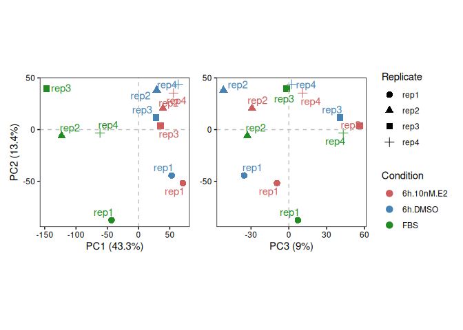

```r
plot.PC.scatter.123(DEprot.PCA.object = PCA,
                    color.column = "condition",
                    shape.column = "replicate",
                    label.column = "replicate",
                    dot.colors = c("6h.10nM.E2" = "indianred",
                                   "6h.DMSO" = "steelblue",
                                   "FBS" =  "forestgreen"),
                    plot.zero.line.y.12 = TRUE,
                    plot.zero.line.x.12 = TRUE,
                    plot.zero.line.y.23 = TRUE,
                    plot.zero.line.x.23 = TRUE)
```

#### 5.1.2.1 PC biplot

It is also possible to visualize the top proteins driving the sample segregation along the PCs using `plot.PC.biplot`. This function overlays protein loading arrows on the PCA scatter: each arrow points in the direction of the protein’s contribution, and its length reflects the magnitude. The `n.loadings` parameter controls how many top contributing proteins should be displayed.

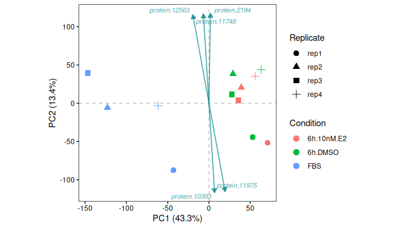

```r
PC_biplot_1.2 <-
  plot.PC.biplot(DEprot.PCA.object = PCA,
                 PC.x = 1,
                 PC.y = 2,
                 color.column = "condition",
                 shape.column = "replicate",
                 label.column = NULL,
                 n.loadings = 5,
                 plot.zero.line.x = TRUE,
                 plot.zero.line.y = TRUE)

PC_biplot_1.2
```

### 5.1.3 Analyze PCs on a sample subset

These analyses can also be performed for a subset of samples by indicating the sample names of interest.  
In the example below we will use only the samples in which the estrogen receptor is active (E2 and FBS conditions).

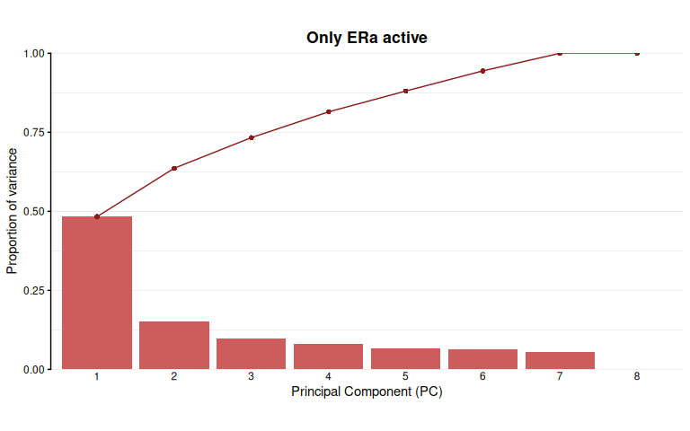

```r
## Perform the analyses (DEprot.PCA object)
PCA.fbs.e2 <-
  perform.PCA(DEprot.object = dpo,
              sample.subset = dpo@metadata$column.id[grepl("E2|FBS",
                                                           dpo@metadata$column.id)],
              which.data = "imputed")


## Plot cumulative variance of all PCs
plot.PC.cumulative(DEprot.PCA.object = PCA.fbs.e2,
                   bar.color = "indianred",
                   line.color = "firebrick4",
                   title = "**Only ERa active**")
```

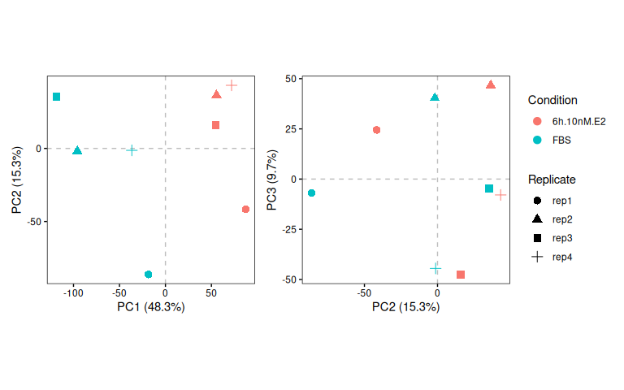

```r
## Plot PC scatters
PC.fbs.e2_1.2 <-
  plot.PC.scatter(DEprot.PCA.object = PCA.fbs.e2,
                  PC.x = 1,
                  PC.y = 2,
                  color.column = "condition",
                  shape.column = "replicate",
                  label.column = NULL,
                  plot.zero.line.x = TRUE,
                  plot.zero.line.y = TRUE) +
  theme(legend.position = "none")


PC.fbs.e2_2.3 <-
  plot.PC.scatter(DEprot.PCA.object = PCA.fbs.e2,
                  PC.x = 2,
                  PC.y = 3,
                  color.column = "condition",
                  shape.column = "replicate",
                  label.column = NULL,
                  plot.zero.line.x = TRUE,
                  plot.zero.line.y = TRUE)

patchwork::wrap_plots(PC.fbs.e2_1.2, PC.fbs.e2_2.3, nrow = 1)
```

## 5.2 Correlations

Another method to define the sample clustering/groups is the overall correlation between the samples.  
Hierarchical clustering is performed using the `1 - correlation` values, since the hierarchical clustering algorithm is based on dissimilarities while the correlations are an index of similarity.

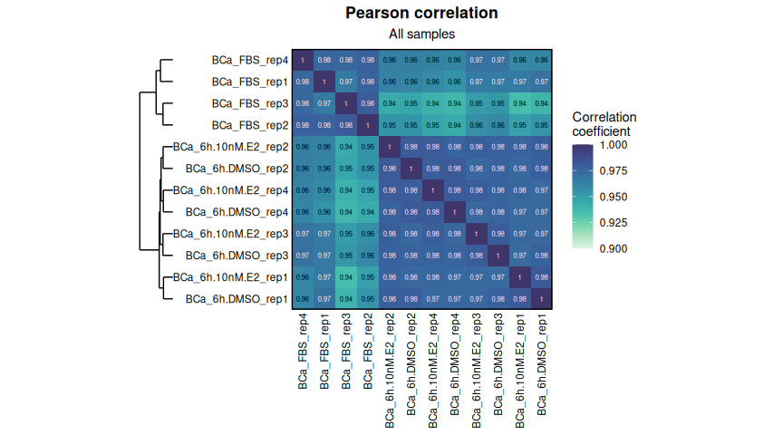

```r
corr.all.samples <-
  plot.correlation.heatmap(DEprot.object = dpo,
                           which.data = "imputed",
                           palette = viridis::mako(n = 10, direction = -1, begin = 0.25),
                           correlation.scale.limits = c(0.9,1),
                           correlation.method = "pearson",
                           plot.subtitle = "All samples",
                           display.values = TRUE)
corr.all.samples
```

Also in this case the sample correlation can be computed for a subset of samples as shown before for the PCAs.

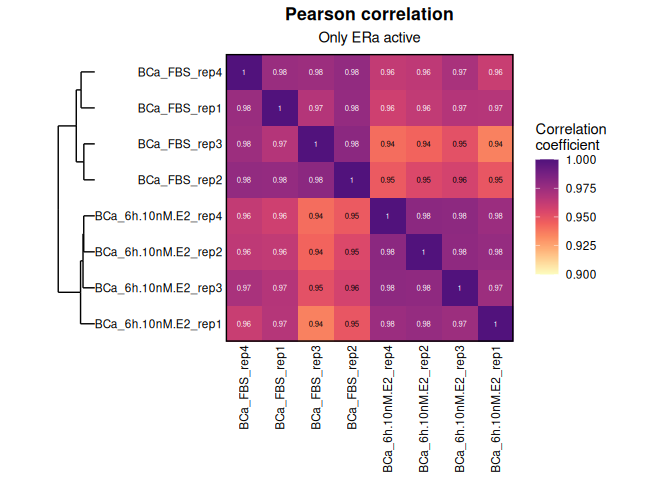

```r
corr.ERa.active <-
  plot.correlation.heatmap(DEprot.object = dpo,
                           which.data = "imputed",
                           sample.subset = dpo@metadata$column.id[grepl("E2|FBS",
                                                                        dpo@metadata$column.id)],
                           palette = viridis::magma(n = 10, direction = -1, begin = 0.25),
                           correlation.scale.limits = c(0.9,1),
                           correlation.method = "pearson",
                           plot.subtitle = "Only ERa active",
                           clustering.method = "complete",
                           display.values = TRUE)

corr.ERa.active
```

The `DEprot.correlation` object contains the following slots:

| Slot | Description |
| --- | --- |
| *heatmap* | `ggplot` object corresponding to the correlation heatmap |
| *corr.metadata* | metadata of the samples used in the correlation (subset of the original `DEprot@metadata`) |
| *sample.subset* | vector containing the list of samples analyzed |
| *data.used* | vector indicating the type of counts used (imputed, normalized, raw) |
| *corr.matrix* | the correlation matrix on which the heatmap is based |
| *distance* | object of class `dist` corresponding to the output of `as.dist(1 - correlation.matrix)` |
| *cluster* | `hclust` object generated by `hclust(d = as.dist(1 - correlation.matrix), method = clustering.method)` |
| *method* | String indicating the correlation method used (one among: pearson, spearman, kendall) |

## 5.3 Principal Coordinate Analyses (PCoA)

The same correlation object can be used as input for a Principal Coordinate Analysis (PCoA, or classical multidimensional scaling). Differently from the PCA, which relies on the Euclidean distances between samples, PCoA ordinates the `1 - correlation` dissimilarity already stored in the `DEprot.correlation` object - a distance that on LFQ data is often more robust, since it looks at how the samples co-vary rather than at their absolute intensities. The `perform.PCoA` function reads the correlation object directly; the original `dpo` object is required only to compute the protein projections shown in the biplot.

```r
## Perform the analyses (DEprot.PCoA object)
PCoA.ERa.active <- perform.PCoA(DEprot.correlation.object = corr.ERa.active,
                                DEprot.object = dpo) # needed only for the biplot
```

Because `1 - correlation` is a dissimilarity rather than a true metric, the ordination can return negative eigenvalues; `perform.PCoA` reports them and computes the variance percentages from the positive ones. When they are sizeable, `distance.transformation = "sqrt"` (or one of the `correction` methods) brings the distances back into euclidean space.

The `DEprot.PCoA` object parallels the `DEprot.PCA` one, and stores in addition the input distance, the eigenvalue diagnostics and a set of ready-made plots:

| Slot | Description |
| --- | --- |
| *PCos* | data.frame combining the principal coordinates and the metadata, useful for replotting |
| *distance* | `dist` object effectively used for the ordination |
| *importance* | summary table per coordinate (eigenvalue, % variance, cumulative, broken-stick) |
| *euclidean.diagnostics* | number and magnitude of the negative eigenvalues, and goodness-of-fit |
| *axis.loadings* | protein-vs-coordinate projections (only if a `DEprot` object was provided) |
| *scatter.plot* | scatter of the two coordinates chosen at the `perform.PCoA` call (PCo2 vs PCo1 by default); a single `ggplot` |
| *scatter.plot.123* | the PCo1-vs-PCo2 and PCo3-vs-PCo2 scatters side by side, sharing PCo2 on the y-axis (a `patchwork`); `NULL` when fewer than three coordinates are available |
| *cumulative.PCo.plot* | barplot of the variance carried by each coordinate, with the cumulative curve and the broken-stick reference drawn on top (`ggplot`) |
| *shepard.plot* | embedding-quality check: the input dissimilarities against the distances reproduced in the two-coordinate plane, with the 1:1 line and Pearson’s *r* (`ggplot`) |

A PCoA in two coordinates is only an approximation of the full distance matrix, so it is worth checking how faithful that approximation is. The `shepard.plot` compares the original dissimilarities (x-axis) with the distances reproduced in the plane actually plotted (y-axis). The closer the points sit to the dashed 1:1 line, the better those two coordinates preserve the real distances between samples; points falling well below it mean the first coordinates are dropping a good part of the structure, and that either more coordinates or a different `distance.transformation` are worth inspecting. The Pearson’s *r* reported in the subtitle summarizes this agreement in a single value.

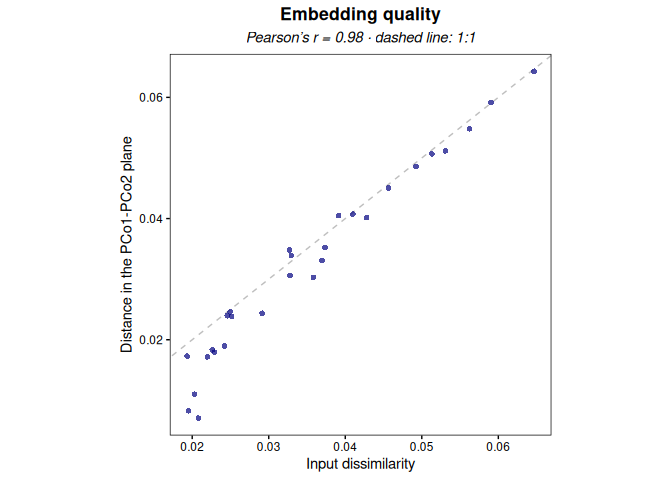

```r
PCoA.ERa.active@shepard.plot
```

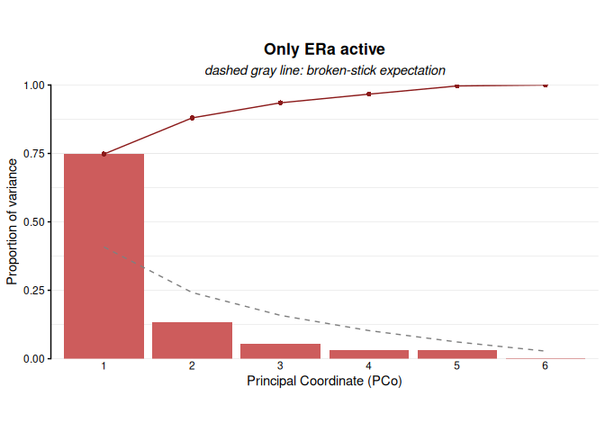

```r
## Plot cumulative variance of all PCos
#### equivalent to `PCoA.ERa.active@cumulative.PCo.plot`
plot.PCoA.cumulative(DEprot.PCoA.object = PCoA.ERa.active,
                     bar.color = "indianred",
                     line.color = "firebrick4",
                     title = "**Only ERa active**")
```

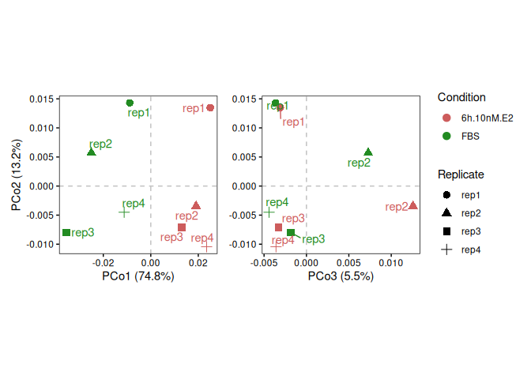

```r
## Combined PCo1-vs-PCo2 and PCo3-vs-PCo2 scatters
#### equivalent to `PCoA.ERa.active@scatter.plot.123`
plot.PCoA.scatter.123(DEprot.PCoA.object = PCoA.ERa.active,
                      color.column = "condition",
                      shape.column = "replicate",
                      label.column = "replicate",
                      dot.colors = c("6h.10nM.E2" = "indianred",
                                     "FBS" = "forestgreen"))
```

A single pair of coordinates can also be drawn on its own with `plot.PCoA.scatter(DEprot.PCoA.object = PCoA.ERa.active, PCo.x = 1, PCo.y = 2, ...)`.

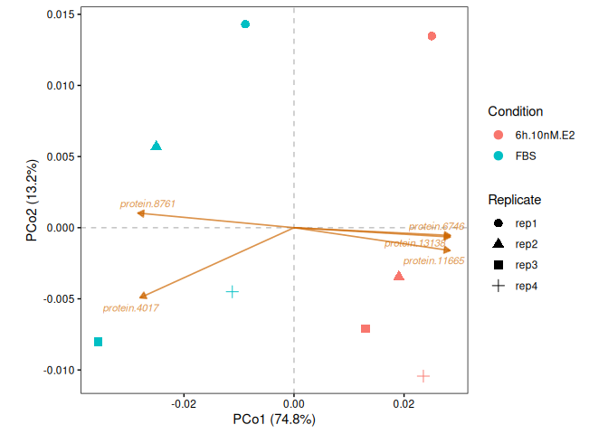

```r
## Top proteins associated with the separation (projection onto the PCos)
PCoA_biplot_1.2 <- plot.PCoA.biplot(DEprot.PCoA.object = PCoA.ERa.active,
                                    PCo.x = 1,
                                    PCo.y = 2,
                                    color.column = "condition",
                                    shape.column = "replicate",
                                    label.column = NULL,
                                    n.loadings = 5)
PCoA_biplot_1.2
```

Unlike the PCA biplot, these arrows represent the a-posteriori correlation between each protein and the coordinates (not the `prcomp` rotation coefficients), so they indicate the direction a protein follows in the ordination rather than an exact loading.

## 5.4 Sparse PLS-DA

PCA and PCoA are unsupervised: they show the largest source of variability in the data, whatever it is. On a proteomics dataset that is often a batch, a difference in identification depth, or one sample that behaves badly, and the treatment ends up on the third or fourth component when it appears at all. A sparse Partial Least Squares Discriminant Analysis (sPLS-DA) asks the opposite question: given the groups, which directions separate them, and which proteins are responsible.

The “sparse” part is what makes the method useful here. A plain PLS-DA gives every one of the thousands of quantified proteins a non-null coefficient, which is not a result one can act on. The sparsity penalty keeps only `keepX` proteins per component and sets the others to exactly zero, so the model returns a short candidate list along with the separation.

```r
## Perform the analyses (DEprot.sPLSDA object)
splsda <- perform.sPLSDA(DEprot.object = dpo,
                         group.column = "condition",
                         which.data = "imputed",
                         ncomp = 3,
                         keepX = NULL,                          # tuned by cross-validation
                         test.keepX = c(10, 20, 50, 100),
                         reference.group = "FBS",
                         validate = TRUE,
                         folds = 4,
                         nrepeat = 5,
                         seed = 1234)
```

Two things happen inside that call besides the fit itself. When `keepX` is left to `NULL`, the number of proteins to retain on each component is chosen by cross-validation over the grid given in `test.keepX`; and when `validate = TRUE`, a second resampling round estimates how well the model actually classifies. Neither of the two changes as long as the model does not change, which is why they are not separate functions: keeping them apart would only mean carrying three objects that must be kept in sync by hand. Both steps resample the samples, so they are the expensive part of the call; `validate = FALSE` skips the second one while exploring.

The design has 4 replicates per condition, hence `folds = 4`: asking for more folds than the samples available in a class produces empty folds, and the function caps the value on its own rather than returning an error rate estimated on nothing.

The data must be complete. A missing value would be handled differently at every fold, which makes the error rates incomparable, and `perform.sPLSDA` stops rather than returning a number that looks fine and is not. Use `which.data = "imputed"`, and see the imputation section if the object does not carry an imputed table yet.

`ncomp` is raised to 3 when a lower value is asked for. A two-group design does not stop at one component: the following ones keep being extracted from the deflated matrix, and they are what shows whether the separation rests on a single protein module or on several. The third component is also what tells whether the tidy picture of the first two is the whole story.

```r
summary(splsda)
```

**sPLS-DA summary, component by component**

| component | keepX | n.selected | perc.variance.X | perc.variance.Y | overall.error | balanced.error |
| --- | --- | --- | --- | --- | --- | --- |
| 1 | 10 | 10 | 39.61 | 50.00 | 0.3333333 | 0.3333333 |
| 2 | 50 | 50 | 4.54 | 50.00 | 0.0333333 | 0.0333333 |
| 3 | 10 | 10 | 8.70 | 0.46 | 0.0000000 | 0.0000000 |

The `DEprot.sPLSDA` object contains the following slots:

| Slot | Description |
| --- | --- |
| *sPLSDA.metadata* | metadata of the samples used in the model |
| *group.column* / *groups* | the metadata column holding the classes, and the classes themselves |
| *splsda* | the `mixo_splsda` object returned by `mixOmics`, in its original orientation |
| *plsda* | the companion non-sparse model, fitted on the same data (see below) |
| *components* | data.frame combining the sample scores and the metadata, useful for replotting |
| *loadings* | loadings of the sparse model, with the class in which each selected protein is the highest (`contrib.group`) |
| *full.loadings* | loadings and VIP scores of the non-sparse model, over every protein of the matrix |
| *selected.proteins* | named list of the proteins retained on each component |
| *importance* | proportion of variance explained by each component, for the protein block (X) and the class block (Y) |
| *counts.used* | the log2 matrix effectively used, after removal of the proteins carrying no information |
| *tuning* | grid of `keepX` tested and the corresponding error; `NULL` when `keepX` was given |
| *performance* | cross-validated error rates, selection frequencies across the folds and AUC; `NULL` when `validate = FALSE` |
| *cumulative.plot*, *scatter.plot.123*, *tuning.plot*, *performance.plot* | ready-made plots |
| *parameters* | list of the parameters used to fit the model |

### 5.4.1 Orientation of the components

`mixOmics` returns an arbitrary sign for each component, so the same data fitted twice can put the same group on opposite sides. `perform.sPLSDA` fixes the sign so that `reference.group` always sits on the positive side, which also gives the loadings a stable reading: a protein with a positive coefficient is a protein pulling the samples towards that group. Here `FBS` was chosen, so a positive loading marks a protein higher in full media. The object stored in the `splsda` slot keeps the original mixOmics orientation, so anything computed on it directly stays consistent with the mixOmics documentation.

### 5.4.2 Reading the tuning

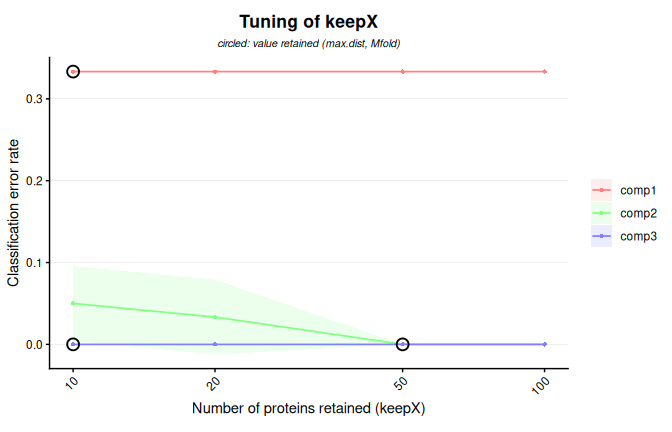

```r
## equivalent to `splsda@tuning.plot`
plot.sPLSDA.tuning(DEprot.sPLSDA.object = splsda)
```

The curves are usually flat over a wide range of values: many different numbers of proteins classify the samples equally well, and the minimum picked by the tuning is one point on a plateau rather than an optimum. This is worth a look, because a value at the left edge of that plateau gives a shorter and far more interpretable protein list at no cost in error rate. Once a value has been chosen, it can be passed directly and the tuning skipped:

```r
splsda.fixed <- perform.sPLSDA(DEprot.object = dpo,
                               group.column = "condition",
                               keepX = c(20, 20, 10),
                               reference.group = "FBS",
                               folds = 4,
                               nrepeat = 5)
```

### 5.4.3 Visualize the model

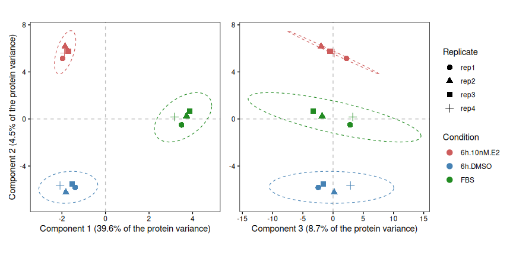

```r
## Combined comp1-vs-comp2 and comp3-vs-comp2 scatters
#### equivalent to `splsda@scatter.plot.123`
plot.sPLSDA.scatter.123(DEprot.sPLSDA.object = splsda,
                        shape.column = "replicate",
                        dot.colors = c("6h.10nM.E2" = "indianred",
                                       "6h.DMSO" = "steelblue",
                                       "FBS" = "forestgreen"))
```

A single pair of components can be drawn on its own with `plot.sPLSDA.scatter`, and `plot.sPLSDA.biplot` adds the loading arrows of the selected proteins on top of it, in the same way as `plot.PC.biplot` does for a PCA. Only the proteins retained on at least one of the two components displayed can appear: a protein dropped by the sparsity penalty has a coefficient of exactly zero and no direction to point to.

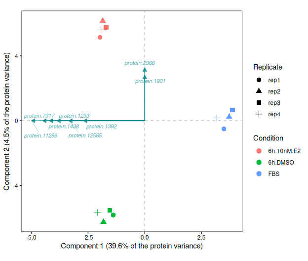

```r
plot.sPLSDA.biplot(DEprot.sPLSDA.object = splsda,
                   comp.x = 1,
                   comp.y = 2,
                   shape.column = "replicate",
                   n.loadings = 8)
```

> The ellipses drawn around the groups are a reading aid, not a test. A supervised model is fitted precisely to separate those samples, so the groups will look tidy on the training data even when the model classifies no better than chance. This is the single most common way of over-reading a PLS-DA, and the reason why the error rates below are not optional.

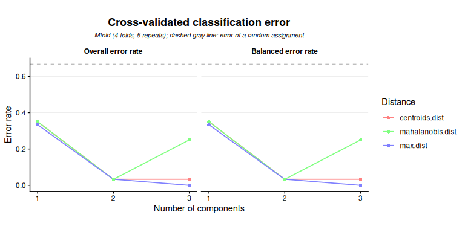

```r
## equivalent to `splsda@performance.plot`
plot.sPLSDA.performance(DEprot.sPLSDA.object = splsda)
```

Two error rates are reported. The overall one is the fraction of misclassified samples; the balanced one (BER) is the average of the per-class error rates, and it is the value to read on an unbalanced design, where a model assigning everything to the largest group already scores well on the overall error. The dashed gray line marks the error of a random assignment, and a model sitting on it is not discriminating anything however clean its scatter looks. The three curves correspond to the three prediction distances that `mixOmics` computes; they usually agree, and a strong disagreement between them is itself worth investigating.

The area under the ROC curve, computed over the same resampling, gives the same message on a scale that does not depend on the class sizes. On a design with more than two classes each curve compares one class against all the others pooled.

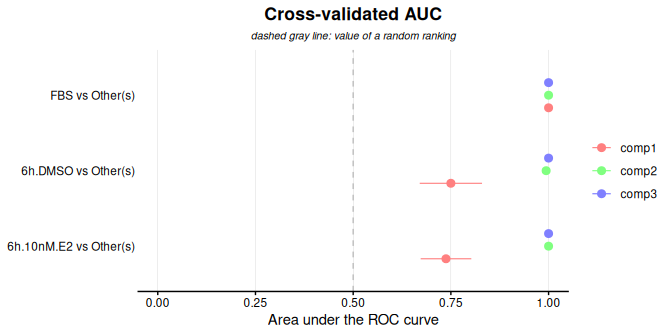

```r
plot.sPLSDA.auroc(DEprot.sPLSDA.object = splsda)
```

### 5.4.4 The proteins behind the separation

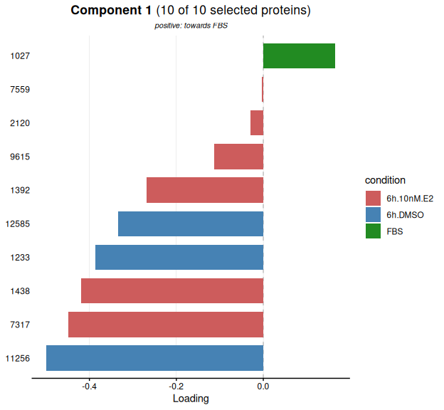

```r
plot.sPLSDA.loadings(DEprot.sPLSDA.object = splsda,
                     component = 1,
                     n.proteins = 20,
                     protein.names.pattern = "protein[.]",
                     group.colors = c("6h.10nM.E2" = "indianred",
                                      "6h.DMSO" = "steelblue",
                                      "FBS" = "forestgreen"))
```

Each bar is the coefficient of a selected protein, colored by the class in which that protein has the highest median. The color carries the information the coefficient alone does not: a large loading says a protein weighs on the component, not in which group it is abundant.

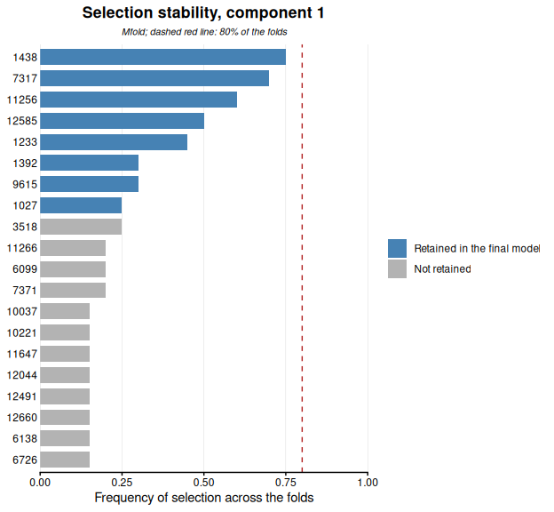

```r
plot.sPLSDA.stability(DEprot.sPLSDA.object = splsda,
                      component = 1,
                      n.proteins = 20,
                      protein.names.pattern = "protein[.]")
```

This second plot is the one to read before writing anybody’s name in a figure legend. The list returned by a sparse model is much less stable than it looks: on a small design, resampling the samples is often enough to swap half of it. A protein re-selected in nearly every fold is a candidate worth following up; one appearing in a third of them is a property of that particular split. Proteins frequently selected during the resampling but absent from the final model are shown as well, since they are exactly the ones a slightly different dataset would have picked.

The loadings come out as an ordinary table, and the selected proteins as a plain character vector, which is what the rest of the package expects. `get.sPLSDA.results` also accepts a `DEprot.object` and a `protein.info.columns` argument, to append the protein annotation in the same way as `get.results` does for the differential tables.

```r
## Full table of the loadings of the first component
get.sPLSDA.results(DEprot.sPLSDA.object = splsda, component = 1)

## Proteins retained on the first component, higher in the reference group
markers <- get.sPLSDA.proteins(DEprot.sPLSDA.object = splsda,
                               component = 1,
                               direction = "positive",
                               top.n = 15)
markers
```

**Loadings of the first component (best-ranked proteins)**

| prot.id | component | loading | abs.loading | selected | contrib.group |
| --- | --- | --- | --- | --- | --- |
| protein.11256 | 1 | -0.4984687 | 0.4984687 | TRUE | 6h.DMSO |
| protein.7317 | 1 | -0.4488427 | 0.4488427 | TRUE | 6h.10nM.E2 |
| protein.1438 | 1 | -0.4196616 | 0.4196616 | TRUE | 6h.10nM.E2 |
| protein.1233 | 1 | -0.3858617 | 0.3858617 | TRUE | 6h.DMSO |
| protein.12585 | 1 | -0.3340929 | 0.3340929 | TRUE | 6h.DMSO |
| protein.1392 | 1 | -0.2691796 | 0.2691796 | TRUE | 6h.10nM.E2 |

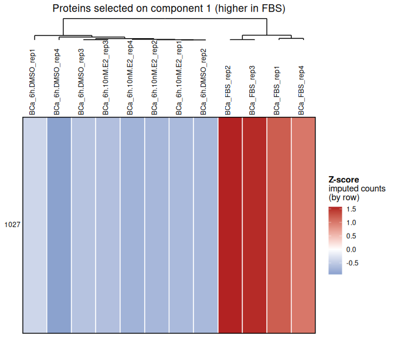

```r
heatmap.counts(DEprot.object = dpo,
               which.data = "imputed",
               protein.subset = markers,
               scale = "row",
               show.protein.names = TRUE,
               protein.names.pattern = "protein[.]",
               cell.border.color = "white",
               title = "Proteins selected on component 1 (higher in FBS)")
```

The same vector can be crossed with the differential results through `plot.upset`, which is usually the most informative check of all: proteins that are both differential and selected are the solid core of the signature, while proteins selected but not differential are the ones the multivariate model sees and a protein-by-protein test does not, typically because they move together with others rather than far on their own.

## 5.5 Automatic outlier detection

PCAs, PCoAs and correlation heatmaps show which samples behave oddly, but the call is left to the eye of the analyst. The function `detect.outliers` turns that judgement into a reproducible one: it computes three per-sample quality metrics and flags a sample when at least `min.flags` of them are triggered.

The three metrics are deliberately independent from each other:

- the **median correlation** of a sample against the others (or against the replicates of its own group, if `group.column` is provided) catches samples whose global profile does not look like anybody else’s;
- the **Mahalanobis distance** in the space of the first principal components catches samples that sit far from the bulk of the data in the reduced space, even when their pairwise correlations look acceptable;
- the **missing rate** catches samples with a poor identification depth, which is often the underlying cause of the other two.

```r
outliers <- detect.outliers(DEprot.object = dpo,
                            which.data = "imputed",
                            group.column = "condition",
                            correlation.method = "pearson",
                            n.PCs = 3,
                            min.flags = 2)

outliers
> DEprot.outliers object:
>   Samples analyzed:  12
>          Data used:  imputed (log2)
>  Metrics available:  correlation, mahalanobis, missingness
>     Flags required:  2
>           Outliers:  none
>
> Sample metrics:
>              column.id      group median.correlation correlation.z
> 1         BCa_FBS_rep3        FBS          0.9750531   -1.22859738
> 2         BCa_FBS_rep2        FBS          0.9780257    0.13478569
> 3         BCa_FBS_rep1        FBS          0.9757698   -0.89986923
> 4         BCa_FBS_rep4        FBS          0.9757698   -0.89986923
> 5  BCa_6h.10nM.E2_rep1 6h.10nM.E2          0.9754252   -1.05793021
> 6     BCa_6h.DMSO_rep1    6h.DMSO          0.9779139    0.08352015
> 7     BCa_6h.DMSO_rep2    6h.DMSO          0.9788311    0.50419354
> 8  BCa_6h.10nM.E2_rep3 6h.10nM.E2          0.9792024    0.67449076
> 9     BCa_6h.DMSO_rep4    6h.DMSO          0.9765005   -0.56471947
> 10 BCa_6h.10nM.E2_rep4 6h.10nM.E2          0.9797022    0.90374172
> 11    BCa_6h.DMSO_rep3    6h.DMSO          0.9775497   -0.08352015
> 12 BCa_6h.10nM.E2_rep2 6h.10nM.E2          0.9792024    0.67449076
>    mahalanobis.distance mahalanobis.padj missing.rate missingness.z n.flags
> 1            20.1504952      0.001895736   0.07053461    0.55672253       1
> 2            15.3267337      0.009346123   0.05415637   -1.71299241       1
> 3             8.3620074      0.156374392   0.07787392    1.57381177       0
> 4             6.3002220      0.293649387   0.05322930   -1.84146684       0
> 5             2.8431555      0.914294061   0.06512670   -0.19271165       0
> 6             2.3025317      0.914294061   0.06644005   -0.01070620       0
> 7             1.7696995      0.914294061   0.06883498    0.32118608       0
> 8             1.4661432      0.914294061   0.06659456    0.01070620       0
> 9             1.2929409      0.914294061   0.08312732    2.30183354       0
> 10            0.8041797      0.914294061   0.07694685    1.44533734       0
> 11            0.7791483      0.914294061   0.06605377   -0.06423722       0
> 12            0.5208202      0.914294061   0.06080037   -0.79225899       0
>    outlier
> 1    FALSE
> 2    FALSE
> 3    FALSE
> 4    FALSE
> 5    FALSE
> 6    FALSE
> 7    FALSE
> 8    FALSE
> 9    FALSE
> 10   FALSE
> 11   FALSE
> 12   FALSE
```

The three panels are stored in the `plot` slot and can be printed with the `plot` method. Samples are ordered by the number of flags they collected, so the suspicious ones sit on the left; the dashed red lines mark the thresholds effectively applied.

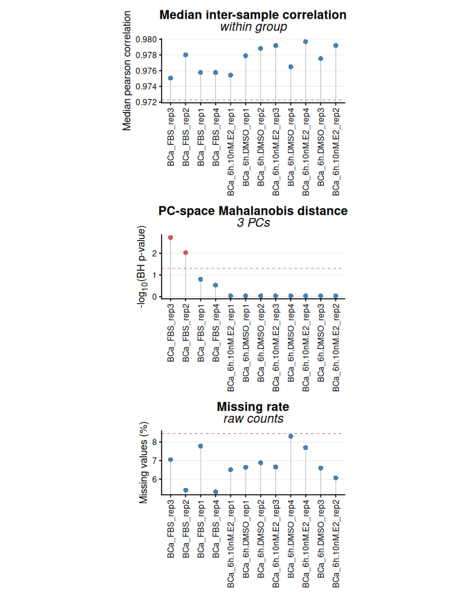

```r
plot(outliers)
```

### 5.5.1 How the thresholds work

The correlation and the missingness are flagged on a **robust Z-score**, `(x - median(x)) / mad(x)`, computed across all the samples: `correlation.z.th = -2.5` means “2.5 robust standard deviations *below* the typical median correlation”, and `missingness.z.th = 2.5` the symmetric condition on the missing rate. A relative threshold adapts to the dispersion of the experiment, which is exactly what one wants when comparing a deeply-sequenced whole-cell run to a sparse RIME. When an absolute limit is preferable, `correlation.min` and `missingness.max` can be set on top of the Z-scores; the two conditions are combined with an OR.

The Mahalanobis distances are treated differently. Since the principal components returned by `perform.PCA` are orthogonal by construction, the covariance matrix reduces to its diagonal and can be estimated robustly from the median and the MAD of each component. This avoids the singularity that a full covariance matrix would produce whenever the number of samples approaches the number of components, which is the normal situation in proteomics. The resulting squared distances follow a chi-square distribution with as many degrees of freedom as the components used, so the flag is set on an adjusted p-value (`mahalanobis.padj.th`) rather than on an arbitrary cut-off.

> On small designs the chi-square approximation is fairly liberal, and a single flag is not by itself a reason to discard a sample. This is why `min.flags` defaults to 2: agreement between two independent metrics is a much stronger signal than any of them alone. Set `min.flags = 1` to obtain a list of *candidates* to inspect manually, and `min.flags = 3` to keep only the unambiguous cases.

### 5.5.2 Missing values and imputed data

The correlation and the PCA are computed on the counts requested with `which.data` (by default the imputed ones), but the missing rate obviously cannot be: after imputation there are no missing values left. The function therefore looks for the first unimputed table available, in the order raw → normalized → randomized, and reports which one it used in the `missingness.data.used` slot. If the object was loaded already imputed, the metric is silently dropped and `min.flags` is capped to the number of metrics that could actually be computed.

### 5.5.3 Removing the flagged samples

The `outliers` slot contains a plain character vector, which is what `filter.samples` expects. The whole pipeline (normalization, randomization, imputation, batch harmonization and, for a `DEprot.analyses` object, the differential analyses) is recomputed from the raw counts on the retained samples only:

```r
dpo.clean <- filter.samples(DEprot.object = dpo,
                            samples = outliers@outliers,
                            mode = "remove")
```

Re-running `detect.outliers` on the filtered object is a reasonable sanity check, keeping in mind that a relative threshold will always find *something* at the tail of the distribution: an empty list of flags at `min.flags = 2` is what should be expected, not an empty list at `min.flags = 1`.

The `DEprot.outliers` object contains the following slots:

| Slot | Description |
| --- | --- |
| *metrics* | data.frame with the three metrics, their Z-scores/p-values, the individual flags, the number of flags and the final call, per sample |
| *outliers* | vector of the samples called as outliers |
| *sample.subset* | vector containing the list of samples analyzed |
| *data.used* | vector indicating the type of counts used (imputed, normalized, raw) |
| *correlation.method* | String indicating the correlation method used (one among: pearson, spearman, kendall) |
| *correlation.matrix* | the sample-by-sample correlation matrix used for the median correlations, diagonal set to `NA` |
| *PCA* | the `DEprot.PCA` object generated internally and used for the Mahalanobis distances |
| *missingness.data.used* | type of counts used to quantify the missing values, `NA` when no unimputed table was available |
| *group.column* | metadata column used to restrict the correlations to the replicates of the same group, `NULL` when all the samples were used |
| *metrics.available* | logical vector indicating which of the three metrics could effectively be computed |
| *parameters* | list of the thresholds applied |
| *plot* | `patchwork` object combining the diagnostic plots of all the metrics available |
| *plot.list* | list of the individual `ggplot` objects, one per metric |

# 6 **Differential Expression (DE) analyses**

Differential expression analyses between two conditions can be performed employing four different methods using the functions `diff.analyses`, `diff.analyses.limma`, `diff.analyses.prolfqua` and `diff.analyses.proDA`.

1. `diff.analyses` the conditions will be compared two-by-two (individual t-/Wilcox tests);
2. `diff.analyses.limma` the `limma` package is used to fit the data to a linear model;
3. `diff.analyses.prolfqua` the `prolfqua` package is used to fit the data to a linear model, a mixed-effects model or a logistic regression, depending on the `strategy` indicated;
4. `diff.analyses.proDA` the `proDA` package is used to fit a censored model, in which the missing values are read as observations below the detection limit instead of being replaced.

The first two methods require complete observations, hence imputed counts, while the last two can be applied to data that still contain missing values. For `diff.analyses.proDA` this is in fact a requirement: the missing values are themselves the input of the model, and the function stops when imputed or randomized counts are indicated (see the dedicated paragraph).

In all cases, it is sufficient to provide a list of three-element vectors. The latter should indicate any column of the metadata table (grouping factor) and two values (groups) to compare within this column. The first variable will be numerator and the second the denominator of the fold change: `c("group.column", "condition.A", "condition.B")`, FoldChange = group A/B.

When a replicate column is available, it is possible to run the analyses in *paired* mode, although the way the replicate enters the model depends on the method. When using `diff.analyses`, it is sufficient to indicate the column from the metadata table that corresponds to the replicate identifiers (in our example `replicate.column = "replicate"`) and set `paired.test = TRUE`. For each contrast it will be verified that replicate identifiers are not repeated within a group and that replicate number and identifiers coincide between the two groups. By default, analyses ignore the replicates.  
If `diff.analyses.limma` is used instead, the correlation between replicates will be estimated and incorporated in the fitting model. In this case indicate the replicate column identifier (in our example `replicate.column = "replicate"`) and set `include.rep.model = TRUE`.  
`diff.analyses.prolfqua` treats the replicate as a random effect of the model (`log_protein_abundance ~ Group + (1|rep)`), which is obtained by indicating the replicate column identifier and setting `strategy = "lmer"`.  
`diff.analyses.proDA` adds instead the replicate as a blocking fixed effect: as for `limma`, indicate the replicate column identifier and set `include.rep.model = TRUE`.

> In the following example we will compare *6h.10nM.E2* vs *6h.DMSO*, and *6h.10nM.E2* vs *FBS*. Both paired and unpaired examples are shown, but further analyses are based on the paired results only (multi t-test mode).

## 6.1 Differential analyses algorithms

### 6.1.1 Multiple t-test/wilcoxon mode

> Next paragraphs use these results, in paired mode

```r
## Unpaired test
dpo_analyses <- diff.analyses(DEprot.object = dpo,
                              contrast.list = list(c("condition", "6h.10nM.E2", "6h.DMSO"),
                                                   c("condition", "6h.10nM.E2", "FBS")),
                              linear.FC.th = 2,
                              padj.th = 0.05,
                              padj.method = "BH",
                              stat.test = "t.test",
                              which.data = "imputed")

## Paired test
dpo_analyses <- diff.analyses(DEprot.object = dpo,
                              contrast.list = list(c("condition", "6h.10nM.E2", "6h.DMSO"),
                                                   c("condition", "6h.10nM.E2", "FBS")),
                              replicate.column = "replicate",
                              paired.test = TRUE,
                              linear.FC.th = 2,
                              padj.th = 0.05,
                              padj.method = "BH",
                              stat.test = "t.test",
                              which.data = "imputed")

dpo_analyses
```

```
> DEprot.analyses object:
>           Counts used:  imputed
> Fold Change threshold:  2 (linear)
> FC unresponsive range:  [0.9090909,1.1] (linear)
>        padj threshold:  0.05 (linear)
>           padj method:  BH
>
>
> Differential results summary:
>   n.contrast                      contrast.id group.factor     group1  group2
> 1          1 condition: 6h.10nM.E2 vs 6h.DMSO    condition 6h.10nM.E2 6h.DMSO
> 2          1 condition: 6h.10nM.E2 vs 6h.DMSO    condition 6h.10nM.E2 6h.DMSO
> 3          1 condition: 6h.10nM.E2 vs 6h.DMSO    condition 6h.10nM.E2 6h.DMSO
> 4          1 condition: 6h.10nM.E2 vs 6h.DMSO    condition 6h.10nM.E2 6h.DMSO
> 5          2     condition: 6h.10nM.E2 vs FBS    condition 6h.10nM.E2     FBS
> 6          2     condition: 6h.10nM.E2 vs FBS    condition 6h.10nM.E2     FBS
> 7          2     condition: 6h.10nM.E2 vs FBS    condition 6h.10nM.E2     FBS
> 8          2     condition: 6h.10nM.E2 vs FBS    condition 6h.10nM.E2     FBS
>   paired.test  diff.status     n median.FoldChange
> 1        TRUE      6h.DMSO     0                NA
> 2        TRUE   6h.10nM.E2     0                NA
> 3        TRUE unresponsive  8486       0.004313803
> 4        TRUE         null  4458       0.150214925
> 5        TRUE          FBS   259      -1.277483222
> 6        TRUE   6h.10nM.E2   284       1.231843519
> 7        TRUE unresponsive  2330      -0.012852350
> 8        TRUE         null 10071      -0.188121421
```

The summary can be collected by using the generic function `summary`:

```r
diff.analyses_summary <- summary(dpo)
```

### 6.1.2 `limma` mode

#### 6.1.2.1 Verify normality of the data

The main assumption to run `limma` is that the data are normally distributed. For this reason it is good practice to verify that the data are normally distributed for each sample. This can be accomplished using the function `check.normality`. It will return an S4 vector composed of:

- `norm.statement`: logical value indicating whether all the samples are normally distributed (TRUE) or not (FALSE);
- `norm.AD.tests`: list of Anderson-Darling normality test outputs (statistics, p-value, etc.);
- `qqplots`: a list of Q-Q plots (ggplot objects) showing the “correlation” between the distribution of your data and the theoretical normal distribution;
- `densities`: a list of density curves (ggplot objects) depicting the distribution of your data and the overlay with the theoretical normal distribution.

> When a sample is not normally distributed (p-value of the AD normality test < p.threshold) the plot will be red instead of black/blue. Furthermore, a message will tell if all samples are normally distributed; and if not, which ones are not normally distributed.  
> However, due to the large number of data used for the normality-test, the p-value can easily lead to the rejection of the null hypothesis (H<sub>0</sub>: distribution is normal). What we suggest is to visually inspect the distribution of the data and identify large/extreme deviations from the theoretical normal distribution (e.g., skewed, bimodal or uniform distributions).

```r
normality <- check.normality(DEprot.object = dpo,
                             p.threshold = 0.05,
                             which.data = "imputed",
                             verbose = TRUE)
> The following samples do not display a normal distribution: BCa_FBS_rep1, BCa_6h.DMSO_rep1, BCa_6h.10nM.E2_rep1, BCa_FBS_rep2, BCa_6h.DMSO_rep2, BCa_6h.10nM.E2_rep2, BCa_FBS_rep3, BCa_6h.DMSO_rep3, BCa_6h.10nM.E2_rep3, BCa_FBS_rep4, BCa_6h.DMSO_rep4, BCa_6h.10nM.E2_rep4.
```

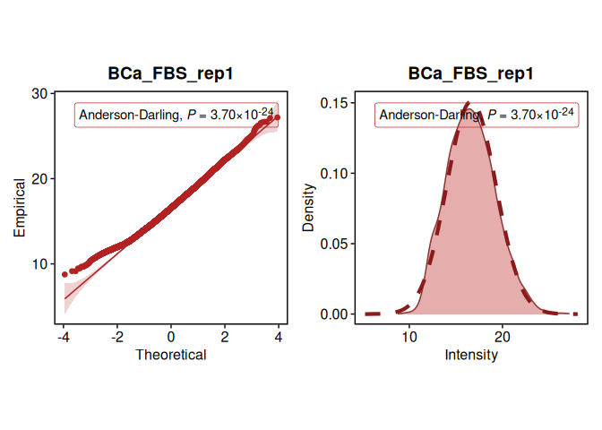

```r
## example of Q-Q and density plots
plot(normality, n.samples = 1)
```

#### 6.1.2.2 Run analyses with `limma`

```r
## Unpaired test
dpo_analyses <- diff.analyses.limma(DEprot.object = dpo,
                                    contrast.list = list(c("condition", "6h.10nM.E2", "6h.DMSO"),
                                                         c("condition", "6h.10nM.E2", "FBS")),
                                    linear.FC.th = 2,
                                    padj.th = 0.05,
                                    padj.method = "BH",
                                    fitting.method = "ls",
                                    which.data = "imputed")

## Paired test
dpo_analyses <- diff.analyses.limma(DEprot.object = dpo,
                                    contrast.list = list(c("condition", "6h.10nM.E2", "6h.DMSO"),
                                                         c("condition", "6h.10nM.E2", "FBS")),
                                    replicate.column = "replicate",
                                    include.rep.model = TRUE,
                                    linear.FC.th = 2,
                                    padj.th = 0.05,
                                    padj.method = "BH",
                                    fitting.method = "ls",
                                    which.data = "imputed")
```

> **NOTE**: Alongside the usual `stats::p.adjust` methods, `diff.analyses.limma()` accepts `padj.method = "fdrtool"`. When you set it, the moderated *t*-statistics from limma are passed to `fdrtool::fdrtool()` as normal deviates, and its tail-area q-values go into the `padj` column in place of the Benjamini-Hochberg values (the per-protein local FDR is kept alongside in `lfdr`). Everything downstream — the volcano, the MA plot, the `diff.status` calls — still reads from `padj`, so changing the method doesn’t change how you use the result.  
> The reason to reach for it is the empirical null. BH assumes the null is exactly the theoretical one; fdrtool instead estimates how many proteins are genuinely null and refits the null distribution from the data itself. That matters most with imputed counts, where imputation shrinks the variance and pushes the statistic distribution away from the textbook null; the case where a fixed-null correction tends to be miscalibrated.  
> It isn’t always the right call. fdrtool needs a fair number of statistics to fit anything sensible: below 200 proteins the function falls back to BH for that contrast and warns you, and even a few hundred proteins give a shaky fit. Treat it as a method for full-proteome comparisons, not small targeted panels. And when the statistic distribution already looks well behaved, plain BH is the more conventional choice and easier to reproduce or compare against other tools.  
> As a rule of thumb: thousands of proteins on imputed data, `fdrtool` is worth trying and often better calibrated; a small protein set, or a case where you just want a standard correction, stay with BH.

## 6.2 `prolfqua` mode

The third method relies on [`prolfqua`](https://pubs.acs.org/doi/10.1021/acs.jproteome.2c00441) (Wolski *et al.*, J Proteome Research 2023), a package written specifically for label-free quantitation data. A model is fitted protein by protein on the two groups of the contrast, and the comparison is then extracted as a contrast of the fitted coefficients. Two features distinguish it from `diff.analyses.limma`: the model to fit can be chosen among four alternatives through the `strategy` parameter, and the fit tolerates missing values, so the analyses can be run on normalized counts without passing through the imputation.

```r
dpo_prolfqua <-
  diff.analyses.prolfqua(DEprot.object = dpo_imputed,
                         contrast.list = list(c("condition", "FBS", "6h.DMSO"),
                                              c("condition", "6h.10nM.E2", "6h.DMSO")),
                         strategy = "lm",
                         linear.FC.th = 1.5,
                         FDR.th = 0.05,
                         which.data = "imputed")
```

Notice that the threshold on the multiple-testing correction is indicated through `FDR.th` and not `padj.th`: the correction is computed by `prolfqua` itself and cannot be changed from here, which is also the reason why this function has no `padj.method` parameter. Consistently, the column of the `results` table is called `FDR` instead of `padj`.

### 6.2.1 Choice of the model

The `strategy` parameter defines the formula and the estimator used for the fit:

| Strategy | Model |
| --- | --- |
| `lm` | linear model, `log_protein_abundance ~ Group` (default) |
| `rlm` | robust linear model on the same formula, less sensitive to outlying replicates |
| `lmer` | linear mixed-effects model, `log_protein_abundance ~ Group + (1\|rep)`, in which the replicate is a random effect |
| `logistf` | Firth’s bias-reduced logistic regression, `log_protein_abundance ~ Group + rep` |

The strategies `lmer` and `logistf` need the replicate identifiers, hence a `replicate.column` must be indicated:

```r
dpo_prolfqua <-
  diff.analyses.prolfqua(DEprot.object = dpo_imputed,
                         contrast.list = list(c("condition", "6h.10nM.E2", "6h.DMSO")),
                         strategy = "lmer",
                         replicate.column = "replicate",
                         linear.FC.th = 1.5)
```

Independently from the strategy, `moderate.variance = TRUE` moderates the variance of the contrast across all the proteins, in the same spirit as the empirical Bayes moderation of `limma`. The `statistic` column then reports the moderated t-statistic, and `lfcSE` the corresponding moderated standard error.

### 6.2.2 Re-normalization applied by prolfqua

Before fitting the model, `prolfqua` re-normalizes each sample: the median of the sample is subtracted, and the values are divided by the median absolute deviation (MAD) of the sample expressed relatively to the average MAD of the samples. The dispersion of the samples is equalized in this way, which is a reasonable default for counts that arrive raw, but on counts already normalized within *DEprot* it is a second normalization that has not been asked for. The centering is harmless once the samples are median-aligned; the division by the MAD is not, because it rescales each sample by a different factor and therefore modifies the estimated fold changes.

The step can be skipped with `robust.scaling = FALSE`, and this is the recommended choice whenever `which.data` points to counts that have been normalized:

```r
dpo_prolfqua <-
  diff.analyses.prolfqua(DEprot.object = dpo_norm,
                         contrast.list = list(c("condition", "FBS", "6h.DMSO")),
                         strategy = "lm",
                         robust.scaling = FALSE,
                         which.data = "normalized")
```

The factors that the scaling applies to each sample are stored for every contrast, whether the scaling has been performed or not, and can be inspected to decide whether the question is relevant for a given dataset:

```r
dpo_prolfqua@analyses.result.list$condition_FBS.vs.6h.DMSO$prolfqua.out$scaling.factors
```

> The effect is stronger on imputed counts. The imputation replaces the missing values with values drawn from the low tail of the distribution, which shrinks the MAD of a sample proportionally to the number of values that were replaced: the samples are not imputed to the same extent, so the rescaling ends up following the pattern of the missing values.

### 6.2.3 Analyses on unimputed data

Being able to fit a model in the presence of missing values, `prolfqua` can be applied to counts that have not been imputed, and the proteins for which too few observations are available are simply left out of the results:

```r
dpo_prolfqua <-
  diff.analyses.prolfqua(DEprot.object = dpo_norm,
                         contrast.list = list(c("condition", "FBS", "6h.DMSO")),
                         strategy = "lm",
                         robust.scaling = FALSE,
                         which.data = "normalized")
```

> The missing values are ignored, not modelled: the estimates are computed on the replicates in which the protein was detected, as if the others had never been measured. When the missing values are concentrated in one of the two groups this is an optimistic assumption, and the model described in the dropout-aware analyses paragraph is the more appropriate choice. Run `missingness.diagnostic` to decide which of the two situations applies to your data.

### 6.2.4 Reading the results

The `results` table contains the same columns as the other differential functions, with `FDR` in place of `padj`. Notice that `log2(FoldChange)` and `statistic` come from the model, hence from the scale on which the model was fitted, while `basemean.log2`, `log2.mean.<group>`, `sd.<group>` and `sem.<group>` are computed by *DEprot* directly on the counts stored in the object. With `robust.scaling = FALSE` the difference between the two group means and the reported fold change coincide; with the scaling active they remain close without being identical.

Differently from `diff.analyses.limma` and `diff.analyses.proDA`, which build the design on all the samples of the metadata column, here the counts and the metadata are filtered on the two groups of the contrast before the fit: each contrast is an independent analysis, and the samples of the other groups do not contribute to the estimates.

For each contrast the analyses list contains an extra `prolfqua.out` element:

| Element | Description |
| --- | --- |
| *LFQ.data* | the `LFQData` object after the transformation applied by `prolfqua` |
| *scaling.factors* | median, MAD and scaling factor of each sample of the contrast |
| *model* | the fitted model |
| *contrast* | the contrast object, moderated or not depending on `moderate.variance` |
| *full.results* | the complete contrast table returned by `prolfqua`, including the columns not kept in `results` |

## 6.3 Dropout-aware analyses without imputation (`proDA`)

`diff.analyses.proDA` takes the other route and never fills the blanks. A missing value is read as the statement *“this protein was below the detection limit in this sample”*, which is a left-censored observation, the same object handled by a survival model when a patient is still alive at the end of the study: the exact value is unknown, only the fact that it lies below a threshold. The probability of detecting a protein at a given intensity is described by a sigmoidal dropout curve estimated separately for each sample, the group means are inferred on the mixture of measured and censored observations, and the uncertainty on the censored ones stays inside the model and propagates into `lfcSE`. A protein detected in one replicate out of three therefore receives a wide standard error and a modest p-value instead of a suspiciously significant one. The implementation relies on [`proDA`](https://bioconductor.org/packages/release/bioc/html/proDA.html) (Ahlmann-Eltze & Anders, 2020).

> The counts selected through `which.data` must still contain the missing values, since they are what the model reads: the function stops when imputed or randomized counts are indicated, because in that case there is nothing left to censor. What else the object contains is irrelevant, so an object carrying also the randomized and the imputed counts can be used as it is, as long as `which.data` points to the normalized (default) or the raw counts.

```r
dpo_proDA <-
  diff.analyses.proDA(DEprot.object = dpo_norm,
                      contrast.list = list(c("condition", "FBS", "6h.DMSO"),
                                           c("condition", "6h.10nM.E2", "6h.DMSO")),
                      linear.FC.th = 1.5,
                      padj.th = 0.05,
                      which.data = "normalized")
```

### 6.3.1 When it is worth it

This model answers the question raised by `missingness.diagnostic`: the diagnostic says whether the probability of being missing depends on the intensity, and the answer decides how the blanks should be handled. A steep dropout curve, an `LOD50` sitting in the low tail of the distribution and a high `perc.missing.MNAR` describe left-censored data, and this is the case in which modelling the censoring pays off. When the diagnostic finds no dependency between intensity and missingness, the data are missing at random, imputation is doing a reasonable job and `diff.analyses.limma` on imputed counts is the cheaper and equally valid choice.

The check is performed by the function itself, which raises a warning when the dropout slope is not significant and runs the analyses anyway. The diagnostic is recomputed internally unless it is passed directly, which is the recommended way when it has already been generated:

```r
miss <- missingness.diagnostic(DEprot.object = dpo_norm)

dpo_proDA <-
  diff.analyses.proDA(DEprot.object = dpo_norm,
                      contrast.list = list(c("condition", "FBS", "6h.DMSO")),
                      missingness.object = miss,
                      linear.FC.th = 1.5)
```

The parameters read from the diagnostic (`LOD50`, dropout slope and p-value, percentage of missing values and of MNAR cells) are stored in `differential.analyses.params$missingness.stats`.

### 6.3.2 The model

The design is `~ 0 + <metadata.column>` and is built on all the samples of the column, exactly as in `diff.analyses.limma`: the two groups of the contrast are compared afterwards with a Wald test, and the samples of the other groups still contribute to the hyper-parameters and to the residual degrees of freedom. Contrasts defined on the same metadata column share a single fit, which is computed only once.

Setting `include.rep.model = TRUE` adds the replicate as a blocking fixed effect, the equivalent of a paired design; a `replicate.column` is required.

```r
dpo_proDA <-
  diff.analyses.proDA(DEprot.object = dpo_norm,
                      contrast.list = list(c("condition", "6h.10nM.E2", "6h.DMSO")),
                      include.rep.model = TRUE,
                      replicate.column = "replicate",
                      linear.FC.th = 1.5)
```

Fitting a censored model protein by protein costs considerably more than a linear model, and the difference is measured in minutes rather than seconds on a full dataset. Two parameters control the cost: `n.subsample`, the number of proteins used to estimate the hyper-parameters (the rows are shuffled before the subsampling, so the estimate is not biased by the order of the counts table), and `max.iter`, the maximum number of iterations of the estimation loop. Proteins with fewer than `min.detected` observed values are excluded from the fit and kept in the results table with `NA` statistics.

Also `padj.method = "fdrtool"` is available, and behaves as described for `diff.analyses.limma`.

> The model needs a reasonable number of samples to estimate the dropout curves. With three replicates per group and two groups the estimation can be unstable, so this function is an alternative for well-powered designs rather than a replacement of the default pipeline.

### 6.3.3 Reading the results

The `results` table has the same columns, in the same order, as the other three differential functions, with three additions at the end.

[output not shown]

Two columns change meaning with respect to the other functions. The `log2(FoldChange)` is the contrast estimate of the censored model and not the difference between the observed means: for a protein missing in one of the two groups the two quantities differ substantially, since the model extrapolates below the detection limit instead of averaging the values that happened to be observed. Consistently, `log2.mean.<group>` reports the model-based group means, computed as the average of the fitted values over the samples of each group. The `sd.<group>` and `sem.<group>` columns are instead descriptive and computed on the observed values only, so for an incomplete protein they are estimated on the surviving replicates and remain under-estimated.

For each contrast the analyses list contains an extra `proDA.fit` element, the equivalent of `limma.fit` and `prolfqua.out`:

| Element | Description |
| --- | --- |
| *fit* | the `proDAFit` object returned by `proDA::proDA` |
| *design* | the model matrix used for the fit |
| *contrast* | the contrast vector tested |
| *dropout.curves* | a data.frame with, for each sample, the position and the scale of the fitted dropout curve |
| *full.results* | the complete table returned by `proDA::test_diff`, including `avg_abundance` and `n_obs` |

The `position` of a dropout curve is the intensity at which a sample has 50% probability of detecting a protein, which makes it the per-sample counterpart of the `LOD50` returned by `missingness.diagnostic`; the `scale` describes how sharp the transition between detection and dropout is. The two estimates are obtained in completely different ways, so they are not expected to coincide exactly, but a sample whose position sits far from the others has a detection limit of its own and deserves a look before the results are interpreted.

```r
dpo_proDA@analyses.result.list$condition_FBS.vs.6h.DMSO$proDA.fit$dropout.curves
```

## 6.4 DE results

The output will be a `DEprot.analyses` object. This class is similar to the base `DEprot` one, however 3 slots are now available:

- *contrasts*: corresponds to the list used to define the contrasts, but includes also the IDs of the counts matrix belonging to each subgroup and whether the statistical test was performed in *paired* mode.
- *differential.analyses.params*: a list containing the core parameters used for the differential expression analyses.
- *analyses.result.list*: a list with an element for each contrast including all the results of the differential analyses (see below for details).

The `analyses.result.list`, for each contrast, stores a list with the following elements:

[output not shown]

Depending on the function used, one further element is available and gives access to the model itself:

| Element | Function | Description |
| --- | --- | --- |
| *limma.fit* | `diff.analyses.limma` | the results of `limma::contrasts.fit` |
| *prolfqua.out* | `diff.analyses.prolfqua` | the `LFQData` object after the transformation, the scaling factors of the samples, the fitted model, the contrast object and the complete contrast table |
| *proDA.fit* | `diff.analyses.proDA` | the fitted model, the design and the contrast used, the dropout curve of each sample and the complete table returned by `proDA::test_diff` |

### 6.4.1 DE *results* table

The table with the results of the differential analyses can be retrieved directly from the list in the `DEprot.analyses` object (`dpo_analyses@analyses.result.list$contrast.id$results`) or using the `get.results` function.  
The annotation columns can then be appended to the differential expression tables by `get.results()`, using `protein.info.columns = "all"` or the names of the columns of interest.

```r
## Direct access
results = dpo_analyses@analyses.result.list$condition_6h.10nM.E2.vs.6h.DMSO$results

## Function
results = get.results(dpo_analyses, contrast = 1, protein.info.columns = "all")

head(results)
```

| prot.id | basemean.log2 | log2.mean.6h.10nM.E2 | log2.mean.6h.DMSO | log2.Fold_6h.10nM.E2.vs.6h.DMSO | p.value | padj | statistic | df | diff.status | sd.6h.10nM.E2 | sem.6h.10nM.E2 | sd.6h.DMSO | sem.6h.DMSO | lfcSE |
| --- | --- | --- | --- | --- | --- | --- | --- | --- | --- | --- | --- | --- | --- | --- |
| protein.1 | 18.85442 | 18.91504 | 18.79381 | 0.1212267 | 0.6343233 | 0.9196149 | 0.5275761 | 3 | unresponsive | 0.2912807 | 0.1456404 | 0.3208880 | 0.1604440 | 0.2297804 |
| protein.2 | 23.07808 | 23.08725 | 23.06891 | 0.0183432 | 0.8684339 | 0.9788710 | 0.1802651 | 3 | unresponsive | 0.0590145 | 0.0295072 | 0.1623151 | 0.0811576 | 0.1017567 |
| protein.3 | 15.68530 | 15.65794 | 15.71266 | -0.0547233 | 0.7188219 | 0.9417907 | -0.3956478 | 3 | unresponsive | 0.3143720 | 0.1571860 | 0.2777887 | 0.1388943 | 0.1383131 |
| protein.4 | 21.14521 | 21.09928 | 21.19115 | -0.0918716 | 0.2081759 | 0.7800477 | -1.5987342 | 3 | unresponsive | 0.0759796 | 0.0379898 | 0.0750256 | 0.0375128 | 0.0574652 |
| protein.5 | 19.56669 | 19.62716 | 19.50622 | 0.1209404 | 0.1169602 | 0.7227441 | 2.1835391 | 3 | unresponsive | 0.0554021 | 0.0277010 | 0.1336665 | 0.0668332 | 0.0553873 |
| protein.6 | 15.31225 | 15.32551 | 15.29900 | 0.0265019 | 0.6433323 | 0.9233057 | 0.5130091 | 3 | unresponsive | 0.1279320 | 0.0639660 | 0.1855774 | 0.0927887 | 0.0516598 |

#### 6.4.1.1 Columns of the *results* table

The four differential functions (`diff.analyses`, `diff.analyses.limma`, `diff.analyses.prolfqua`, `diff.analyses.proDA`) all return the same columns, in the same order, and some of them add further columns at the end of the table. `<groupA>` and `<groupB>` stand for the two variables of the contrast.

[output not shown]

Where the means and the fold change come from depends on the function. `diff.analyses` and `diff.analyses.limma` compute both directly on the counts stored in the object. `diff.analyses.prolfqua` computes the means on the counts, while the fold change is estimated on the intensities as rescaled by `prolfqua` for the fit (see the corresponding paragraph). `diff.analyses.proDA` reports means and fold change of the censored model, so that both account for the values that were below the detection limit; the `sd.<group>` and `sem.<group>` columns remain descriptive and are computed on the observed values only, in all four cases.

#### 6.4.1.2 Additional columns

| Column | Returned by | Description |
| --- | --- | --- |
| `lfdr` | `diff.analyses.limma`, `diff.analyses.proDA` | local false discovery rate estimated by `fdrtool`, added only when `padj.method = "fdrtool"` and the estimation succeeded |
| `n.detected.<groupA>`, `n.detected.<groupB>` | `diff.analyses.proDA` | number of samples in which the protein was quantified in each group |
| `n.approx` | `diff.analyses.proDA` | effective sample size estimated by the model over all the samples of the design; it measures how much information the values below the detection limit carry |

#### 6.4.1.3 Notes on `lfcSE`

What `lfcSE` measures depends on the function used, although in every case it is the denominator of the reported `statistic`.

`diff.analyses` returns the standard error used by the t-test itself, so `statistic = log2(FoldChange) / lfcSE`. For unpaired tests this is the Welch standard error and equals `sqrt(sem.<groupA>^2 + sem.<groupB>^2)`; for paired tests it is the standard error of the per-replicate differences, and the two do not coincide. The Wilcoxon test ranks the values instead of modelling them, and no standard error is attached to the fold change: `lfcSE` is `NA` whenever `stat.test = "wilcoxon"`.

`diff.analyses.limma` returns the moderated (posterior) standard error of the contrast coefficient, the same quantity that limma uses as denominator of its moderated *t*. `diff.analyses.prolfqua` returns the standard error of the contrast estimate, moderated when `moderate.variance = TRUE`. `diff.analyses.proDA` returns the standard error of the contrast of the censored model, which includes the uncertainty on the values that were not detected: a protein quantified in a minority of the replicates receives a wide `lfcSE`, where the same protein analyzed on imputed counts would have received a narrow one.

Together with `df`, `lfcSE` gives confidence intervals (CI) on the fold change:

```r
res <- get.results(dpo, contrast = 1)

confidence <- 0.95
alpha <- 1 - confidence
t.crit <- qt(1 - alpha/2, df = res$df)   # upper-tail critical value, per protein

res$CI.lower <- res$log2.Fold_FBS.vs.6h.DMSO - t.crit * res$lfcSE
res$CI.upper <- res$log2.Fold_FBS.vs.6h.DMSO + t.crit * res$lfcSE
```

> One caveat: imputation replaces missing values with conditional estimates that carry no residual noise. Run on imputed counts, `sd`, `sem` and `lfcSE` are all biased downwards, and intervals built from them are narrower than they should be. Modelling the missing values instead of replacing them keeps that uncertainty visible, which is what the dropout-aware analyses are for.

### 6.4.2 PCA and correlation within the comparison

The `DEprot.analyses` object includes PCA and correlation analyses of the samples involved in the contrast.

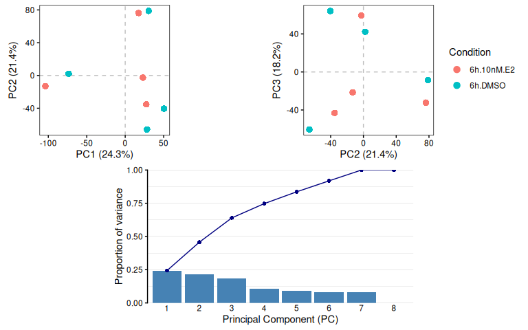

```r
dpo_analyses@analyses.result.list$condition_6h.10nM.E2.vs.6h.DMSO$PCA.plots
```

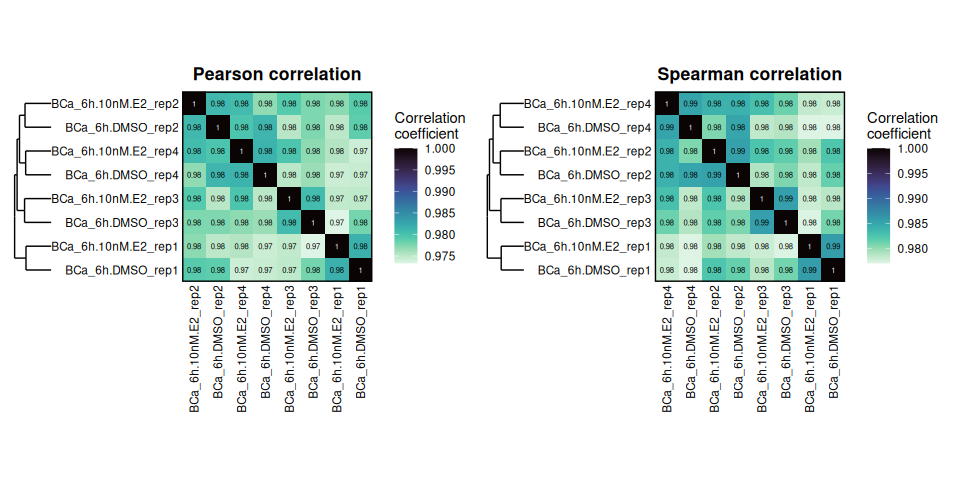

```r
dpo_analyses@analyses.result.list$condition_6h.10nM.E2.vs.6h.DMSO$correlations
```